# Replication of Baker (2016): Czech survey vs. Nature survey

Martin Šmíd (data prep for P. Jedlička)

02. 10. 2026

Comparison of the Czech survey with Baker (2016). Question numbers follow Petr’s memo of 21 Sept 2026.

- **Part 1 – Main results** (for the main text): only answer categories offered in both surveys. “Don’t know” is kept where both surveys offered it (Q6, Q16; “I can’t remember” in Q18–Q20) and excluded where only the Czech survey did (Q8, Q9); Q18–Q20 are restricted to respondents who do experiments; Q5 uses only the four options present in both surveys.
- **Part 2 – Detailed results** (supplementary): the same basis, question by question.
- **Part 3 – Sensitivity analysis**: the same with all answer categories kept.

Field-adjusted Czech results reweight Czech respondents to Baker’s field mix (Q50). Tests and Cramér’s V compare Baker with the unadjusted Czech sample. Both samples are self-selected, so CIs reflect sampling noise only.

Settings for this run: time cutoff = 0 min, basic research only = FALSE, mathematicians dropped = TRUE. Baker N = 1576.

```r
kable(flow, caption = "Czech respondent flow")
```

Czech respondent flow

| Step | N |
| --- | --- |
| dataAll.RData (AV, UK, MU, JU merged; test response removed) | 1021 |
| Mathematicians removed | 975 |

```r
# ---- Versions: which answers are dropped ----
MAIN <- "Main: shared categories only"
ALL  <- "All categories"
CR <- "I can't remember"; NOX <- "I don't do experiments"
v_main     <- setNames(list(DK), MAIN)            # "don't know" offered only in the Czech survey (Q8, Q9)
v_main_kp  <- setNames(list(character(0)), MAIN)  # "don't know" offered in both surveys (Q6, Q16): kept
v_main_exp <- setNames(list(NOX), MAIN)           # Q18-Q20: non-experimenters (Czech only) dropped
v_all      <- setNames(list(character(0)), ALL)

# ---- Answer scales and item labels ----
d <- d %>% mutate(rep_podil = ifelse(rep_podil == DK, DK, paste0(parse_number(rep_podil), "%")))
lv8    <- c(paste0(seq(0, 100, 10), "%"), DK)
crisis <- c("Significant crisis", "Slight crisis", "No crisis", DK)
agree  <- c("Strongly agree", "Agree", "Neither agree nor disagree", "Disagree", "Strongly disagree", DK)
often  <- c("Always", "Very often", "Sometimes", "Rarely", "Never", DK)
yn     <- c("Yes", "No", CR, NOX)
q9 <- c(nerep_problem = "Failure to reproduce is a major problem in my field",
        nerep_chyba   = "Failure to reproduce most often means the original finding is wrong",
        nerep_valid   = "Failure to reproduce rarely detracts from the validity of the original finding")
q16 <- c(fakt_podvod = "Fraud", fakt_karier = "Pressure to publish", fakt_dohled = "Insufficient oversight/mentoring",
         fakt_recenz = "Insufficient peer review", fakt_selekc = "Selective reporting",
         fakt_replik = "Not replicated enough in original lab", fakt_statis = "Low statistical power or poor analysis",
         fakt_odborn = "Mistakes in reproduction efforts", fakt_data = "Raw data not available",
         fakt_dokume = "Protocols, code or reagent info unavailable", fakt_metody = "Methods need special technical expertise",
         fakt_variab = "Variability of standard reagents", fakt_design = "Poor experimental design",
         fakt_smula = "Bad luck")
q1820 <- c(nerep_jaMuj = "Q18: Failed to reproduce own experiment",
           nerep_jaCizi = "Q19: Failed to reproduce someone else's experiment",
           nerep_oniMuj = "Q20: Someone failed to reproduce my results")

# ---- Q5 (multiple choice) ----
q5 <- c(rep_Ne = "No, never heard of it", rep_Mainstream = "Yes, mainstream media",
        rep_Casopisy = "Yes, scientific journals", rep_Diskuse = "Yes, conferences",
        rep_Kolegove = "Yes, colleagues (Baker only)", rep_Jinde = "Yes, elsewhere (Baker only)",
        rep_Vlastni = "Other, own answer (Czech only)")
q5_common <- c("rep_Ne", "rep_Mainstream", "rep_Casopisy", "rep_Diskuse")
cz5 <- cz %>% mutate(field = field(spec_hlavni)) %>% left_join(select(fw, field, w), by = "field") %>%
  select(w, any_of(names(q5))) %>% filter(if_any(any_of(names(q5)), ~ !is.na(.x))) %>%
  mutate(across(any_of(names(q5)), ~ !is.na(.x)), Survey = "Czech")
bk5 <- bk %>% select(any_of(names(q5))) %>% mutate(across(everything(), ~ .x == 1), Survey = "Baker", w = 1)
long5 <- bind_rows(bk5, cz5) %>% pivot_longer(any_of(names(q5)), names_to = "item", values_to = "ticked") %>%
  filter(!is.na(ticked))
long5 <- bind_rows(long5 %>% mutate(wt = 1),
                   long5 %>% filter(Survey == "Czech", !is.na(w)) %>% mutate(Survey = ADJ, wt = w)) %>%
  mutate(Survey = factor(Survey, levels = c("Baker", "Czech", ADJ)))
q5_table <- function(opts) long5 %>% filter(item %in% opts) %>% group_by(Survey, item) %>%
  summarise(pct = round(100 * sum(wt * ticked) / sum(wt), 1), N = n(), .groups = "drop") %>%
  mutate(item = factor(q5[item], levels = rev(q5)))
q5_show <- function(opts, title) {
  t5 <- q5_table(opts)
  p <- ggplot(t5, aes(x = pct, y = item, fill = Survey)) +
    geom_col(position = position_dodge(width = 0.85), width = 0.8) +
    geom_text(aes(label = pct), position = position_dodge(width = 0.85), hjust = -0.15, size = 2.6) +
    scale_fill_manual(values = pal) + scale_x_continuous(expand = expansion(mult = c(0, 0.15))) +
    labs(title = title, x = "% of respondents", y = NULL, fill = NULL,
         caption = paste0("Baker N=", nrow(bk5), ", Czech N=", nrow(cz5),
                          " (Czech: respondents who ticked at least one option)")) +
    theme_minimal() + theme(legend.position = "bottom")
  tab <- t5 %>% select(item, Survey, pct) %>% pivot_wider(names_from = Survey, values_from = pct, names_prefix = "% ")
  list(plot = p, table = tab)
}

# ---- Q8 means ----
wci <- function(x, w = rep(1, length(x))) {
  m <- sum(w * x) / sum(w); n_eff <- sum(w)^2 / sum(w^2)
  se <- sqrt(sum(w * (x - m)^2) / sum(w) * n_eff / (n_eff - 1)) / sqrt(n_eff)
  tibble(N = length(x), mean = m, lo = m - qt(0.975, n_eff - 1) * se, hi = m + qt(0.975, n_eff - 1) * se) }
q8 <- d %>% filter(!is.na(rep_podil), rep_podil != DK) %>% mutate(pct = parse_number(rep_podil))
q8_means <- bind_rows(q8 %>% group_by(Survey) %>% reframe(wci(pct)) %>% mutate(Survey = as.character(Survey)),
                      q8 %>% filter(Survey == "Czech", !is.na(w)) %>% reframe(wci(pct, w)) %>% mutate(Survey = ADJ))

# ---- Cramér's V (bias-corrected, Baker vs unadjusted Czech) ----
cohen <- function(v) cut(v, c(-Inf, 0.1, 0.3, 0.5, Inf),
                         labels = c("negligible", "small", "medium", "large"), right = FALSE)
v_of <- function(survey, value) {
  t <- table(droplevels(factor(survey)), droplevels(factor(value)))
  if (min(dim(t)) < 2) return(tibble(V = NA_real_, lo = NA_real_, hi = NA_real_, nB = NA, nC = NA))
  e <- effectsize::cramers_v(t, adjust = TRUE, ci = 0.95, alternative = "two.sided")
  tibble(V = e[[1]], lo = e$CI_low, hi = e$CI_high, nB = sum(t["Baker", ]), nC = sum(t["Czech", ]))
}
v_var <- function(var, drop) {
  x <- d %>% filter(Survey %in% c("Baker", "Czech"), !is.na(.data[[var]]), !.data[[var]] %in% drop)
  v_of(x$Survey, x[[var]])
}
# Multi-item questions (Q5, Q9, Q16): all items' answers pooled into one distribution
# (Survey x item:answer). Respondents then contribute several answers, so the CI is too narrow.
v_battery <- function(vars, drop) {
  x <- d %>% filter(Survey %in% c("Baker", "Czech")) %>% select(Survey, all_of(vars)) %>%
    mutate(id = row_number())
  nr <- x %>% pivot_longer(all_of(vars), names_to = "item", values_to = "value") %>%
    filter(!is.na(value), !value %in% drop)
  v_of(nr$Survey, paste(nr$item, nr$value, sep = ": ")) %>%
    mutate(nB = n_distinct(nr$id[nr$Survey == "Baker"]), nC = n_distinct(nr$id[nr$Survey == "Czech"]))
}
v_q5 <- function(opts) {
  x <- long5 %>% filter(Survey %in% c("Baker", "Czech"), ticked, item %in% opts)
  v_of(as.character(x$Survey), x$item) %>% mutate(nB = nrow(bk5), nC = nrow(cz5))
}
v_summary <- function(drop_shared, drop_czonly, drop_exp, q5opts) {
  bind_rows(
    v_q5(q5opts) %>% mutate(Question = "Q5", Item = "Heard of the crisis, and where (options as one distribution)"),
    v_var("krize_rep", drop_shared) %>% mutate(Question = "Q6", Item = "Is there a reproducibility crisis?"),
    v_var("rep_podil", drop_czonly) %>% mutate(Question = "Q8", Item = "Share of published results reproducible"),
    v_battery(names(q9), drop_czonly) %>% mutate(Question = "Q9", Item = "Attitude statements (3 items as one distribution)"),
    v_battery(names(q16), drop_shared) %>% mutate(Question = "Q16", Item = "Factors of irreproducibility (14 items as one distribution)"),
    bind_rows(lapply(names(q1820), function(v) v_var(v, drop_exp) %>%
      mutate(Question = substr(q1820[[v]], 1, 3), Item = substring(q1820[[v]], 6))))) %>%
    mutate(Size = cohen(V), Label = paste0(Question, ": ", Item)) %>%
    arrange(parse_number(Question)) %>% mutate(Label = factor(Label, levels = rev(unique(Label))))
}
v_plot <- function(vres, title) {
  vres <- vres %>% mutate(Lab = paste0(Label, "  [", Size, "]"),
                          Lab = factor(Lab, levels = paste0(levels(Label), "  [", Size[match(levels(Label), Label)], "]")))
  ggplot(vres, aes(x = V, y = Lab, colour = Size)) +
    annotate("rect", xmin = -Inf, xmax = 0.1, ymin = -Inf, ymax = Inf, alpha = 0.10) +
    geom_vline(xintercept = c(0.1, 0.3, 0.5), linetype = "dotted", linewidth = 0.3) +
    geom_pointrange(aes(xmin = lo, xmax = hi), size = 0.3) +
    scale_colour_manual(values = c(negligible = "#2E8B57", small = "#4C72B0", medium = "#DD8452", large = "#C44E52"),
                        drop = FALSE) +
    coord_cartesian(xlim = c(0, max(vres$hi, na.rm = TRUE) + 0.05)) +
    labs(title = title, x = "Cramér's V (bias-corrected), 95% CI", y = NULL, colour = NULL,
         caption = "Dotted lines: 0.1 / 0.3 / 0.5 (Cohen: small / medium / large). Shaded: negligible.") +
    theme_minimal() + theme(legend.position = "bottom")
}
v_fmt <- function(vres) vres %>% mutate(`V [95% CI]` = sprintf("%.2f [%.2f, %.2f]", V, lo, hi))

# ---- Headline shares (direction of the difference) ----
share_row <- function(var, hit, drop) {
  x <- d %>% filter(!is.na(.data[[var]]), !.data[[var]] %in% drop)
  b <- x %>% filter(Survey == "Baker"); cc <- x %>% filter(Survey == "Czech"); ca <- cc %>% filter(!is.na(w))
  tibble(Baker = 100 * mean(b[[var]] %in% hit), Czech = 100 * mean(cc[[var]] %in% hit),
         Adj = 100 * weighted.mean(ca[[var]] %in% hit, ca$w))
}
```

# Part 1: Main results

Only answer categories offered in both surveys: “don’t know” kept in Q6 and Q16 and “I can’t remember” in Q18–Q20 (offered in both), excluded in Q8 and Q9 (Czech only); Q18–Q20 experimenters only; Q5 only the four options in both surveys. Size of the difference: one bias-corrected Cramér’s V per question, Baker vs Czech; Cohen’s label in brackets (below 0.1 negligible, 0.1–0.3 small, 0.3–0.5 medium, 0.5+ large). For Q5, Q9 and Q16 all items are pooled into one distribution. Tables are in Part 2.

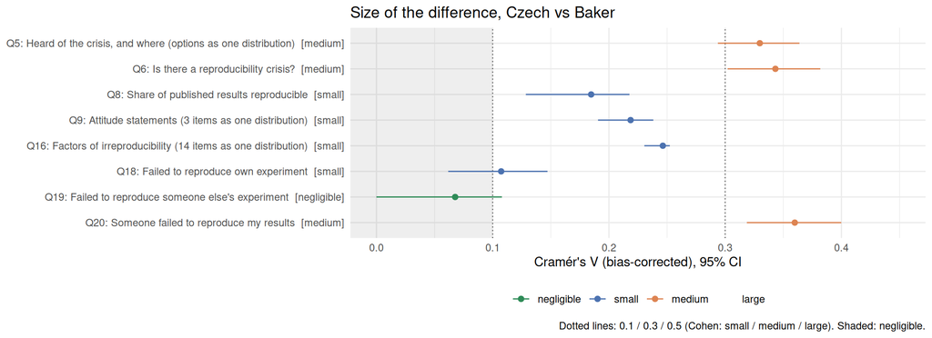

```r
v_plot(vmain, "Size of the difference, Czech vs Baker")
```

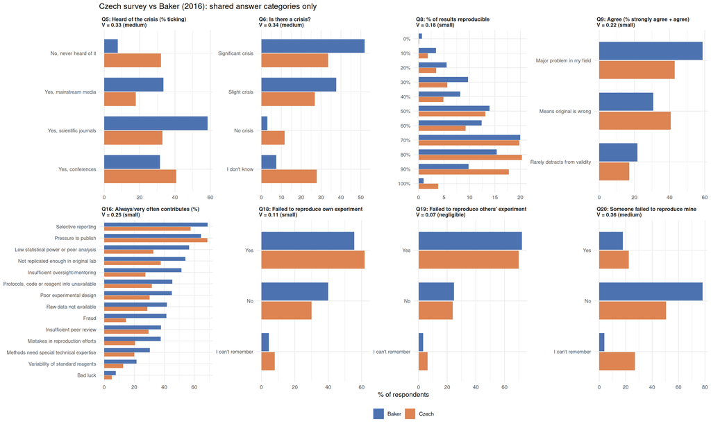

```r
# Miniatures of the Part 2 comparisons (Baker vs unadjusted Czech, shared categories only)
dist <- function(var, drop, lv) d %>% filter(Survey %in% c("Baker", "Czech"), !is.na(.data[[var]]), !.data[[var]] %in% drop) %>%
  count(Survey, cat = .data[[var]]) %>% group_by(Survey) %>% mutate(pct = 100 * n / sum(n)) %>% ungroup() %>%
  mutate(cat = factor(cat, levels = lv)) %>% arrange(cat) %>% mutate(cat = as.character(cat))
item_share <- function(labels, hit, drop) bind_rows(lapply(names(labels), function(v)
  d %>% filter(Survey %in% c("Baker", "Czech"), !is.na(.data[[v]]), !.data[[v]] %in% drop) %>%
    group_by(Survey) %>% summarise(pct = 100 * mean(.data[[v]] %in% hit), .groups = "drop") %>%
    mutate(cat = labels[[v]])))
q9s <- c(nerep_problem = "Major problem in my field", nerep_chyba = "Means original is wrong",
         nerep_valid = "Rarely detracts from validity")
vlab <- function(q) { v <- vmain[vmain$Question == q, ]; sprintf("V = %.2f (%s)", v$V, v$Size) }
panels <- list(
  list(q = "Q5",  t = "Q5: Heard of the crisis (% ticking)",
       x = q5_table(q5_common) %>% filter(Survey != ADJ) %>% transmute(Survey, cat = as.character(item), pct) %>%
             mutate(cat = factor(cat, levels = q5[q5_common])) %>% arrange(cat) %>% mutate(cat = as.character(cat))),
  list(q = "Q6",  t = "Q6: Is there a crisis?", x = dist("krize_rep", character(0), crisis)),
  list(q = "Q8",  t = "Q8: % of results reproducible", x = dist("rep_podil", DK, lv8)),
  list(q = "Q9",  t = "Q9: Agree (% strongly agree + agree)", x = item_share(q9s, c("Strongly agree", "Agree"), DK)),
  list(q = "Q16", t = "Q16: Always/very often contributes (%)", x = item_share(q16, c("Always", "Very often"), character(0))),
  list(q = "Q18", t = "Q18: Failed to reproduce own experiment", x = dist("nerep_jaMuj", NOX, yn)),
  list(q = "Q19", t = "Q19: Failed to reproduce others' experiment", x = dist("nerep_jaCizi", NOX, yn)),
  list(q = "Q20", t = "Q20: Someone failed to reproduce mine", x = dist("nerep_oniMuj", NOX, yn)))
tiles <- bind_rows(lapply(panels, function(p) {
  x <- p$x; if (p$q == "Q16") x <- x %>% group_by(cat) %>% mutate(o = pct[Survey == "Baker"]) %>% ungroup() %>% arrange(desc(o))
  x %>% mutate(Panel = paste0(p$t, "\n", vlab(p$q)), key = paste(p$q, cat, sep = "___"),
               ord = match(cat, unique(x$cat)), q = p$q)
}))
tiles <- tiles %>% mutate(Panel = factor(Panel, levels = unique(Panel)),
                          key = factor(key, levels = rev(unique(key[order(match(q, unique(q)), ord)]))),
                          Survey = factor(Survey, levels = c("Baker", "Czech")))
ggplot(tiles, aes(x = pct, y = key, fill = Survey)) +
  geom_col(position = position_dodge2(width = 0.8, reverse = TRUE, padding = 0.05), width = 0.75) +
  facet_wrap(~ Panel, nrow = 2, ncol = 4, scales = "free") +
  scale_y_discrete(labels = function(k) sub("^.*___", "", k)) +
  scale_fill_manual(values = pal) +
  labs(x = "% of respondents", y = NULL, fill = NULL,
       title = "Czech survey vs Baker (2016): shared answer categories only") +
  theme_minimal(base_size = 10) +
  theme(legend.position = "bottom", strip.text = element_text(face = "bold", hjust = 0),
        axis.text.y = element_text(size = 7.5))
```

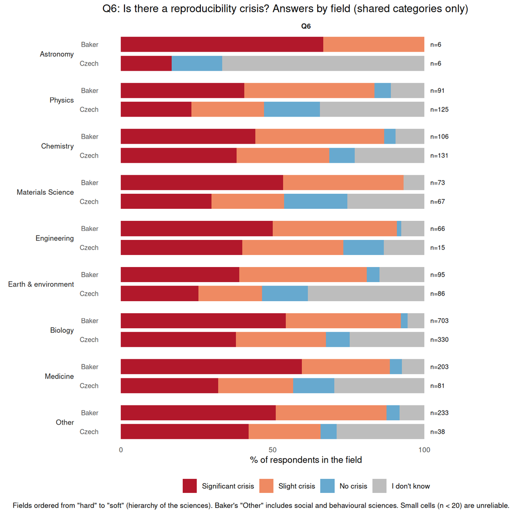

```r
# ---- Answer spectra by field (Q6, Q18, Q19) ----
qf <- c(krize_rep = "Q6", nerep_jaMuj = "Q18", nerep_jaCizi = "Q19", nerep_oniMuj = "Q20")
ans_cols <- c("Significant crisis" = "#B2182B", "Slight crisis" = "#EF8A62", "No crisis" = "#67A9CF",
              "I don't know" = "#BDBDBD", "Yes" = "#762A83", "No" = "#1B7837",
              "I can't remember" = "#D9D9D9", "I don't do experiments" = "#737373")
by_field <- function(drops) bind_rows(lapply(names(qf), function(v)
  d %>% filter(Survey %in% c("Baker", "Czech"), !is.na(field), !is.na(.data[[v]]), !.data[[v]] %in% drops[[v]]) %>%
    count(field, Survey, answer = .data[[v]]) %>% group_by(field, Survey) %>%
    mutate(N = sum(n), pct = 100 * n / N) %>% ungroup() %>% mutate(Q = qf[[v]], var = v)))
# Fields from "hard" to "soft", fixed a priori (hierarchy of the sciences: Comte; Fanelli 2010), "Other" last
hard_order <- c("Mathematics", "Astronomy", "Physics", "Chemistry", "Materials Science", "Engineering",
                "Earth & environment", "Biology", "Medicine", "Other")
field_order <- function(bf) intersect(hard_order, unique(bf$field))
field_plot <- function(bf, qs, title) {
  bf <- bf %>% filter(Q %in% qs)
  bf <- bf %>% mutate(field = factor(field, levels = field_order(bf)), Q = factor(Q, levels = qs),
                      Survey = factor(Survey, levels = c("Czech", "Baker")),
                      answer = factor(answer, levels = names(ans_cols)))
  ns <- bf %>% distinct(field, Q, Survey, N)
  ggplot(bf, aes(x = pct, y = Survey, fill = answer)) +
    geom_col(width = 0.8, orientation = "y", position = position_stack(reverse = TRUE)) +
    geom_text(data = ns, aes(x = 102, y = Survey, label = paste0("n=", N)), inherit.aes = FALSE, hjust = 0, size = 2.5) +
    facet_grid(field ~ Q, switch = "y") +
    scale_fill_manual(values = ans_cols, drop = TRUE, name = NULL) +
    scale_x_continuous(limits = c(0, 122), breaks = c(0, 50, 100)) +
    labs(title = title, x = "% of respondents in the field", y = NULL,
         caption = "Fields ordered from \"hard\" to \"soft\" (hierarchy of the sciences). Baker's \"Other\" includes social and behavioural sciences. Small cells (n < 20) are unreliable.") +
    theme_minimal(base_size = 10) +
    theme(panel.grid = element_blank(), strip.placement = "outside",
          strip.text.y.left = element_text(angle = 0, hjust = 1), strip.text.x = element_text(face = "bold"),
          axis.text.y = element_text(size = 7.5), legend.position = "bottom")
}
# Q18-Q20: field's "yes" share minus the survey's overall "yes" share for the question, 95% CI.
# diff = (n_rest/N) * (p_field - p_rest), so its variance follows from two independent proportions.
qy <- c(nerep_jaMuj = "Q18: Failed to reproduce own experiment",
        nerep_jaCizi = "Q19: Failed to reproduce someone else's experiment",
        nerep_oniMuj = "Q20: Someone failed to reproduce my results")
yes_dev <- function(keep) bind_rows(lapply(names(qy), function(v) {
  x <- d[d$Survey %in% c("Baker", "Czech") & !is.na(d[[v]]) & d[[v]] %in% keep, ]
  x$yes <- x[[v]] == "Yes"
  tot <- x %>% group_by(Survey) %>% summarise(Nall = n(), kall = sum(yes), .groups = "drop")
  x %>% filter(!is.na(field)) %>% group_by(Survey, field) %>% summarise(n = n(), k = sum(yes), .groups = "drop") %>%
    left_join(tot, by = "Survey") %>%
    mutate(pf = k / n, nr = Nall - n, pr = (kall - k) / nr, pall = kall / Nall,
           diff = 100 * (pf - pall), se = 100 * (nr / Nall) * sqrt(pf * (1 - pf) / n + pr * (1 - pr) / nr),
           lo = diff - 1.96 * se, hi = diff + 1.96 * se, Q = qy[[v]])
}))
yes_plot <- function(yd, title, nmin = 20) {
  yd <- yd %>% filter(n >= nmin) %>%
    mutate(field = factor(field, levels = intersect(hard_order, unique(field))),
           Survey = factor(Survey, levels = c("Baker", "Czech")), Q = factor(Q, levels = qy))
  avg <- yd %>% distinct(Q, Survey, pall) %>% arrange(Survey) %>% group_by(Q) %>%
    summarise(lab = paste0("Overall yes: ", paste0(Survey, " ", round(100 * pall), "%", collapse = ", ")), .groups = "drop")
  ggplot(yd, aes(x = field, y = diff, fill = Survey)) +
    geom_hline(yintercept = 0, linewidth = 0.3) +
    geom_col(position = position_dodge(width = 0.8), width = 0.75) +
    geom_errorbar(aes(ymin = lo, ymax = hi), position = position_dodge(width = 0.8), width = 0.25, linewidth = 0.3) +
    geom_text(data = avg, aes(x = -Inf, y = Inf, label = lab), inherit.aes = FALSE, hjust = -0.02, vjust = 1.3, size = 3) +
    facet_grid(Q ~ ., labeller = label_wrap_gen(22)) +
    scale_fill_manual(values = pal) +
    labs(title = title, x = NULL, y = "'Yes' share minus question average (pp), 95% CI", fill = NULL,
         caption = paste0("Average = each survey's overall 'yes' share for the question. ",
                          "Fields ordered from \"hard\" to \"soft\"; cells with n < ", nmin, " omitted.")) +
    theme_minimal(base_size = 10) +
    theme(legend.position = "bottom", axis.text.x = element_text(angle = 30, hjust = 1),
          strip.text.y = element_text(angle = 0, face = "bold"), panel.grid.major.x = element_blank())
}
yes_table <- function(yd) yd %>%
  mutate(field = factor(field, levels = intersect(hard_order, unique(field)))) %>% arrange(Q, field, Survey) %>%
  transmute(Question = Q, Field = field, Survey, n, `Yes %` = round(100 * pf, 1), `Overall yes %` = round(100 * pall, 1),
            `Difference, pp [95% CI]` = sprintf("%.1f [%.1f, %.1f]", diff, lo, hi))
bf_main <- by_field(list(krize_rep = character(0), nerep_jaMuj = NOX, nerep_jaCizi = NOX, nerep_oniMuj = NOX))
field_plot(bf_main, "Q6", "Q6: Is there a reproducibility crisis? Answers by field (shared categories only)")
```

Q18–Q20 by field, level of the “yes” share (95% Wilson CI), with a Kruskal–Wallis test of differences between fields, separately for each survey (“yes” and “no” only; fields with n ≥ 20). With a yes/no answer the Kruskal–Wallis test is equivalent to a chi-square test of homogeneity across fields.

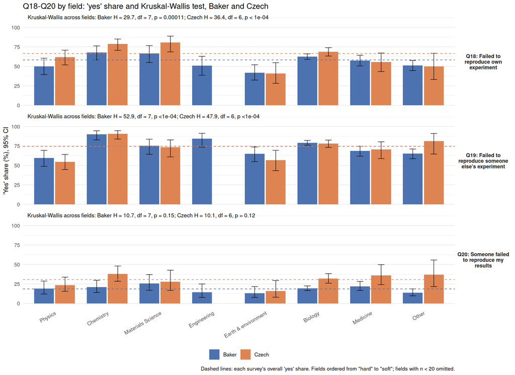

```r
kw_data <- function(keep, nmin = 20) bind_rows(lapply(names(qy), function(v) {
  x <- d[d$Survey %in% c("Baker", "Czech") & !is.na(d[[v]]) & d[[v]] %in% keep & !is.na(d$field), ]
  tibble(Survey = as.character(x$Survey), field = x$field, Q = qy[[v]], yes = as.numeric(x[[v]] == "Yes")) %>%
    group_by(Survey, field) %>% filter(n() >= nmin) %>% ungroup()
}))
kw_tests <- function(kd) kd %>% group_by(Q, Survey) %>%
  reframe({t <- kruskal.test(yes ~ factor(field))
           tibble(H = unname(t$statistic), df = unname(t$parameter), p = t$p.value,
                  Fields = n_distinct(field), N = n())})
wilson <- function(k, n, z = 1.96) {
  p <- k / n; den <- 1 + z^2 / n; c0 <- (p + z^2 / (2 * n)) / den
  h <- z * sqrt(p * (1 - p) / n + z^2 / (4 * n^2)) / den
  list(lo = 100 * (c0 - h), hi = 100 * (c0 + h))
}
kw_plot <- function(kd, title) {
  lev <- kd %>% group_by(Q, Survey, field) %>% summarise(n = n(), k = sum(yes), .groups = "drop") %>%
    mutate(pct = 100 * k / n, lo = wilson(k, n)$lo, hi = wilson(k, n)$hi,
           field = factor(field, levels = intersect(hard_order, unique(field))),
           Survey = factor(Survey, levels = c("Baker", "Czech")), Q = factor(Q, levels = qy))
  avg <- kd %>% group_by(Q, Survey) %>% summarise(m = 100 * mean(yes), .groups = "drop") %>%
    mutate(Survey = factor(Survey, levels = c("Baker", "Czech")), Q = factor(Q, levels = qy))
  lab <- kw_tests(kd) %>% arrange(Survey) %>% group_by(Q) %>%
    summarise(lab = paste0("Kruskal-Wallis across fields: ",
                           paste0(Survey, " H = ", sprintf("%.1f", H), ", df = ", df, ", p ",
                                  ifelse(grepl("^<", fmt_p(p)), "", "= "), fmt_p(p), collapse = "; ")),
              .groups = "drop") %>% mutate(Q = factor(Q, levels = qy))
  ggplot(lev, aes(x = field, y = pct, fill = Survey)) +
    geom_col(position = position_dodge(width = 0.8, preserve = "single"), width = 0.75) +
    geom_errorbar(aes(ymin = lo, ymax = hi), position = position_dodge(width = 0.8, preserve = "single"), width = 0.25, linewidth = 0.3) +
    geom_hline(data = avg, aes(yintercept = m, colour = Survey), linetype = "dashed", linewidth = 0.4, show.legend = FALSE) +
    geom_text(data = lab, aes(x = -Inf, y = Inf, label = lab), inherit.aes = FALSE, hjust = -0.02, vjust = 1.3, size = 3) +
    facet_grid(Q ~ ., labeller = label_wrap_gen(22)) +
    scale_fill_manual(values = pal) + scale_colour_manual(values = pal) +
    scale_y_continuous(limits = c(0, 112), breaks = seq(0, 100, 25)) +
    labs(title = title, x = NULL, y = "'Yes' share (%), 95% CI", fill = NULL,
         caption = "Dashed lines: each survey's overall 'yes' share. Fields ordered from \"hard\" to \"soft\"; fields with n < 20 omitted.") +
    theme_minimal(base_size = 10) +
    theme(legend.position = "bottom", axis.text.x = element_text(angle = 30, hjust = 1),
          strip.text.y = element_text(angle = 0, face = "bold"), panel.grid.major.x = element_blank())
}
kd_main <- kw_data(c("Yes", "No"))
kw_plot(kd_main, "Q18-Q20 by field: 'yes' share and Kruskal-Wallis test, Baker and Czech")
```

# Part 2: Detailed results (supplementary)

Same basis as Part 1: only answer categories offered in both surveys.

## Summary tables

```r
vmain %>% v_fmt() %>% transmute(Question, Item, `N Baker` = nB, `N Czech` = nC, `V [95% CI]`, Size) %>%
  kable(caption = "Size of the difference per question (Cramér's V, bias-corrected). For Q5, Q9 and Q16 items are pooled; respondents give several answers, so these CIs are too narrow.")
```

Size of the difference per question (Cramér’s V, bias-corrected). For Q5, Q9 and Q16 items are pooled; respondents give several answers, so these CIs are too narrow.

| Question | Item | N Baker | N Czech | V [95% CI] | Size |
| --- | --- | --- | --- | --- | --- |
| Q5 | Heard of the crisis, and where (options as one distribution) | 1576 | 884 | 0.33 [0.29, 0.36] | medium |
| Q6 | Is there a reproducibility crisis? | 1576 | 879 | 0.34 [0.30, 0.38] | medium |
| Q8 | Share of published results reproducible | 1576 | 778 | 0.18 [0.13, 0.22] | small |
| Q9 | Attitude statements (3 items as one distribution) | 1576 | 861 | 0.22 [0.19, 0.24] | small |
| Q16 | Factors of irreproducibility (14 items as one distribution) | 1576 | 868 | 0.25 [0.23, 0.25] | small |
| Q18 | Failed to reproduce own experiment | 1576 | 771 | 0.11 [0.06, 0.15] | small |
| Q19 | Failed to reproduce someone else’s experiment | 1576 | 775 | 0.07 [0.00, 0.11] | negligible |
| Q20 | Someone failed to reproduce my results | 1576 | 774 | 0.36 [0.32, 0.40] | medium |

```r
t5m <- q5_table(q5_common) %>% select(item, Survey, pct) %>%
  pivot_wider(names_from = Survey, values_from = pct) %>%
  transmute(Question = "Q5", Item = as.character(item), Headline = "ticked", Baker, Czech, Adj = .data[[ADJ]])
hl <- bind_rows(
  t5m,
  share_row("krize_rep", "Significant crisis", character(0)) %>%
    mutate(Question = "Q6", Item = "Is there a reproducibility crisis?", Headline = "significant crisis"),
  q8_means %>% select(Survey, mean) %>% pivot_wider(names_from = Survey, values_from = mean) %>%
    transmute(Question = "Q8", Item = "Share of published results reproducible", Headline = "mean %",
              Baker, Czech, Adj = .data[[ADJ]]),
  bind_rows(lapply(names(q9), function(v) share_row(v, c("Strongly agree", "Agree"), DK) %>%
    mutate(Question = "Q9", Item = q9[[v]], Headline = "agree"))),
  bind_rows(lapply(names(q16), function(v) share_row(v, c("Always", "Very often"), character(0)) %>%
    mutate(Question = "Q16", Item = q16[[v]], Headline = "always + very often"))),
  bind_rows(lapply(names(q1820), function(v) share_row(v, "Yes", NOX) %>%
    mutate(Question = substr(q1820[[v]], 1, 3), Item = substring(q1820[[v]], 6), Headline = "yes"))))
hl %>% arrange(parse_number(Question)) %>%
  transmute(Question, Item, Headline, Baker = round(Baker, 1), Czech = round(Czech, 1),
            `Czech (field-adj.)` = round(Adj, 1)) %>%
  kable(caption = "Direction of the difference: headline shares in % (Q8: mean estimate in %), shared categories only")
```

Direction of the difference: headline shares in % (Q8: mean estimate in %), shared categories only

| Question | Item | Headline | Baker | Czech | Czech (field-adj.) |
| --- | --- | --- | --- | --- | --- |
| Q5 | Yes, scientific journals | ticked | 58.4 | 32.9 | 37.0 |
| Q5 | Yes, conferences | ticked | 31.5 | 40.7 | 41.9 |
| Q5 | Yes, mainstream media | ticked | 33.5 | 17.8 | 18.2 |
| Q5 | No, never heard of it | ticked | 7.7 | 32.1 | 29.1 |
| Q6 | Is there a reproducibility crisis? | significant crisis | 52.0 | 33.6 | 36.0 |
| Q8 | Share of published results reproducible | mean % | 58.2 | 66.6 | 64.5 |
| Q9 | Failure to reproduce is a major problem in my field | agree | 58.8 | 43.0 | 46.2 |
| Q9 | Failure to reproduce most often means the original finding is wrong | agree | 30.6 | 40.7 | 36.6 |
| Q9 | Failure to reproduce rarely detracts from the validity of the original finding | agree | 21.8 | 17.0 | 17.6 |
| Q16 | Fraud | always + very often | 41.4 | 14.4 | 12.9 |
| Q16 | Pressure to publish | always + very often | 64.4 | 68.7 | 68.3 |
| Q16 | Insufficient oversight/mentoring | always + very often | 51.4 | 27.5 | 27.3 |
| Q16 | Insufficient peer review | always + very often | 37.9 | 29.6 | 30.4 |
| Q16 | Selective reporting | always + very often | 68.8 | 57.5 | 57.6 |
| Q16 | Not replicated enough in original lab | always + very often | 54.1 | 37.6 | 37.7 |
| Q16 | Low statistical power or poor analysis | always + very often | 56.6 | 32.7 | 34.8 |
| Q16 | Mistakes in reproduction efforts | always + very often | 37.7 | 20.6 | 19.6 |
| Q16 | Raw data not available | always + very often | 41.7 | 28.7 | 31.2 |
| Q16 | Protocols, code or reagent info unavailable | always + very often | 45.4 | 31.7 | 35.1 |
| Q16 | Methods need special technical expertise | always + very often | 30.5 | 20.0 | 19.1 |
| Q16 | Variability of standard reagents | always + very often | 21.5 | 12.6 | 12.0 |
| Q16 | Poor experimental design | always + very often | 45.1 | 30.3 | 31.7 |
| Q16 | Bad luck | always + very often | 7.7 | 5.1 | 4.4 |
| Q18 | Failed to reproduce own experiment | yes | 55.6 | 61.9 | 61.3 |
| Q19 | Failed to reproduce someone else’s experiment | yes | 72.1 | 69.8 | 71.6 |
| Q20 | Someone failed to reproduce my results | yes | 18.0 | 22.4 | 23.1 |

## Sample composition (Q50)

Used for sample comparability, not as a substantive replication finding.

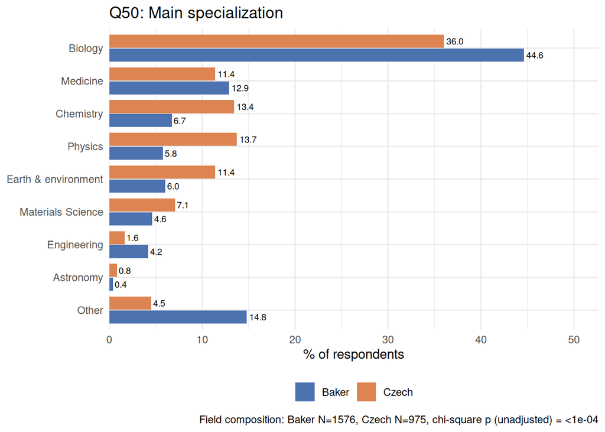

| Answer | n Baker | n Czech | % Baker | % Czech |
| --- | --- | --- | --- | --- |
| Biology | 703 | 351 | 44.6 | 36.0 |
| Medicine | 203 | 111 | 12.9 | 11.4 |
| Chemistry | 106 | 131 | 6.7 | 13.4 |
| Physics | 91 | 134 | 5.8 | 13.7 |
| Earth & environment | 95 | 111 | 6.0 | 11.4 |
| Materials Science | 73 | 69 | 4.6 | 7.1 |
| Engineering | 66 | 16 | 4.2 | 1.6 |
| Astronomy | 6 | 8 | 0.4 | 0.8 |
| Other | 233 | 44 | 14.8 | 4.5 |

```r
fl <- c("Biology", "Medicine", "Chemistry", "Physics", "Earth & environment", "Materials Science",
        "Engineering", "Astronomy", "Mathematics", "Other")
r <- compare_cat("field", fl, title = "Q50: Main specialization",
                 versions = setNames(list(character(0)), "Field composition"), adjust = FALSE)
r$plot + facet_null(); kable(r$table %>% select(-Version))
```

Weights used for the field-adjusted Czech results (weight = Baker share / Czech share):

```r
kable(fw %>% mutate(across(c(Baker, Czech), ~ round(100 * .x, 1)), w = round(w, 2)) %>%
        rename(`Baker %` = Baker, `Czech %` = Czech, Weight = w) %>% arrange(desc(`Baker %`)))
```

| field | Baker % | Czech % | Weight |
| --- | --- | --- | --- |
| Biology | 44.6 | 36.0 | 1.24 |
| Other | 14.8 | 4.5 | 3.28 |
| Medicine | 12.9 | 11.4 | 1.13 |
| Chemistry | 6.7 | 13.4 | 0.50 |
| Earth & environment | 6.0 | 11.4 | 0.53 |
| Physics | 5.8 | 13.7 | 0.42 |
| Materials Science | 4.6 | 7.1 | 0.65 |
| Engineering | 4.2 | 1.6 | 2.55 |
| Astronomy | 0.4 | 0.8 | 0.46 |

## Q5 – Awareness of the reproducibility crisis

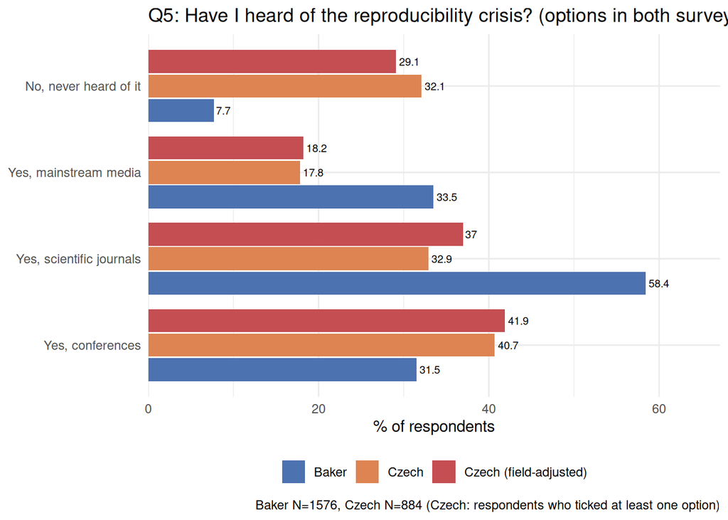

| item | % Baker | % Czech | % Czech (field-adjusted) |
| --- | --- | --- | --- |
| Yes, scientific journals | 58.4 | 32.9 | 37.0 |
| Yes, conferences | 31.5 | 40.7 | 41.9 |
| Yes, mainstream media | 33.5 | 17.8 | 18.2 |
| No, never heard of it | 7.7 | 32.1 | 29.1 |

```r
r <- q5_show(q5_common, "Q5: Have I heard of the reproducibility crisis? (options in both surveys)"); r$plot; kable(r$table)
```

## Q6 – Is there a reproducibility crisis?

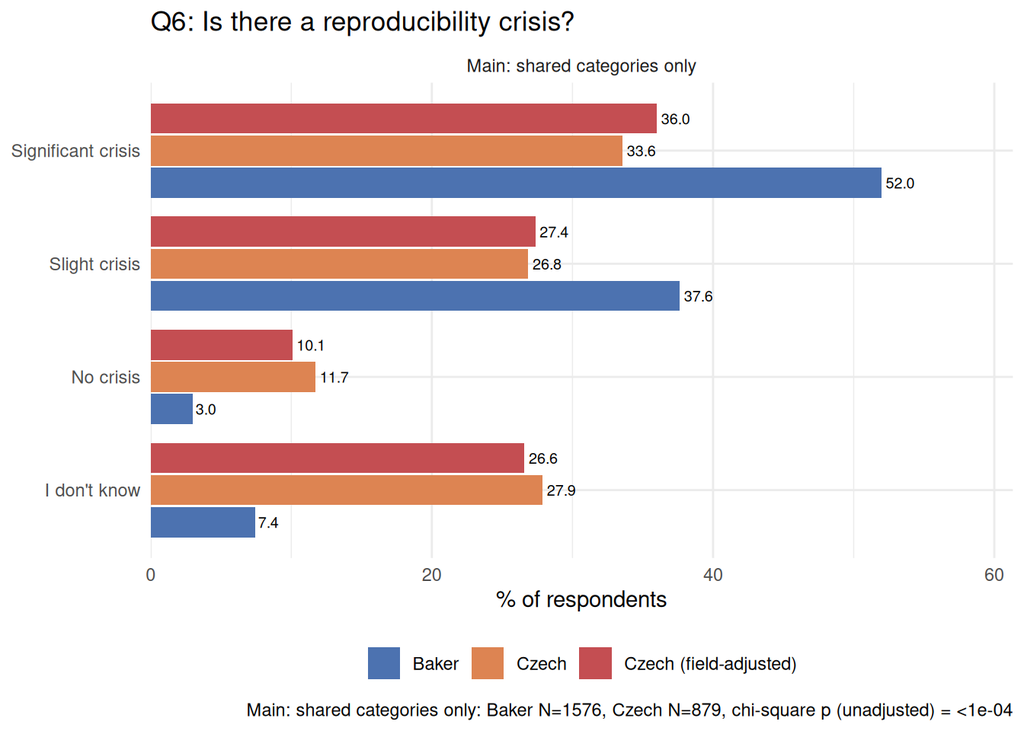

| Version | Answer | n Baker | n Czech | % Baker | % Czech | % Czech (field-adjusted) |
| --- | --- | --- | --- | --- | --- | --- |
| Main: shared categories only | Significant crisis | 819 | 295 | 52.0 | 33.6 | 36.0 |
| Main: shared categories only | Slight crisis | 593 | 236 | 37.6 | 26.8 | 27.4 |
| Main: shared categories only | No crisis | 47 | 103 | 3.0 | 11.7 | 10.1 |
| Main: shared categories only | I don’t know | 117 | 245 | 7.4 | 27.9 | 26.6 |

```r
r <- compare_cat("krize_rep", crisis, versions = v_main_kp, title = "Q6: Is there a reproducibility crisis?"); r$plot; kable(r$table)
```

## Q8 – Share of published results in my field that are reproducible

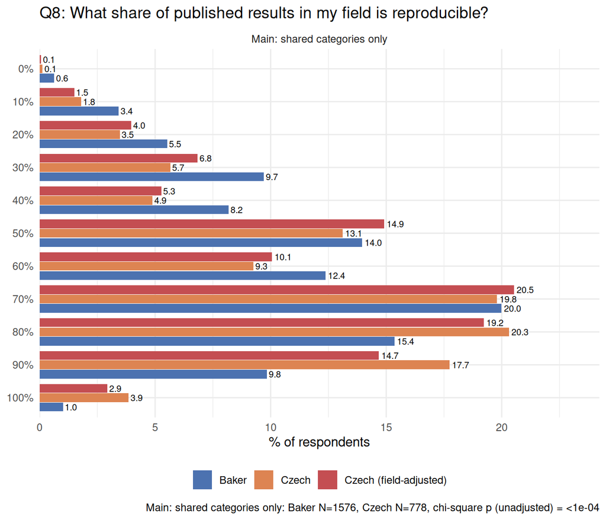

| Version | Answer | n Baker | n Czech | % Baker | % Czech | % Czech (field-adjusted) |
| --- | --- | --- | --- | --- | --- | --- |
| Main: shared categories only | 0% | 10 | 1 | 0.6 | 0.1 | 0.1 |
| Main: shared categories only | 10% | 54 | 14 | 3.4 | 1.8 | 1.5 |
| Main: shared categories only | 20% | 87 | 27 | 5.5 | 3.5 | 4.0 |
| Main: shared categories only | 30% | 153 | 44 | 9.7 | 5.7 | 6.8 |
| Main: shared categories only | 40% | 129 | 38 | 8.2 | 4.9 | 5.3 |
| Main: shared categories only | 50% | 220 | 102 | 14.0 | 13.1 | 14.9 |
| Main: shared categories only | 60% | 195 | 72 | 12.4 | 9.3 | 10.1 |
| Main: shared categories only | 70% | 315 | 154 | 20.0 | 19.8 | 20.5 |
| Main: shared categories only | 80% | 242 | 158 | 15.4 | 20.3 | 19.2 |
| Main: shared categories only | 90% | 155 | 138 | 9.8 | 17.7 | 14.7 |
| Main: shared categories only | 100% | 16 | 30 | 1.0 | 3.9 | 2.9 |

```r
r <- compare_cat("rep_podil", lv8, versions = v_main, title = "Q8: What share of published results in my field is reproducible?")
r$plot; kable(r$table)
```

```r
kable(q8_means %>% mutate(across(where(is.double), ~ round(.x, 1))), caption = "Mean estimate, overall")
```

Mean estimate, overall

| Survey | N | mean | lo | hi |
| --- | --- | --- | --- | --- |
| Baker | 1576 | 58.2 | 57.1 | 59.3 |
| Czech | 778 | 66.6 | 65.0 | 68.1 |
| Czech (field-adjusted) | 778 | 64.5 | 62.7 | 66.3 |

```r
t.test(pct ~ Survey, data = q8)
```

```
##
##  Welch Two Sample t-test
##
## data:  pct by Survey
## t = -8.6923, df = 1613, p-value < 2.2e-16
## alternative hypothesis: true difference in means between group Baker and group Czech is not equal to 0
## 95 percent confidence interval:
##  -10.266467  -6.486205
## sample estimates:
## mean in group Baker mean in group Czech
##            58.17893            66.55527
```

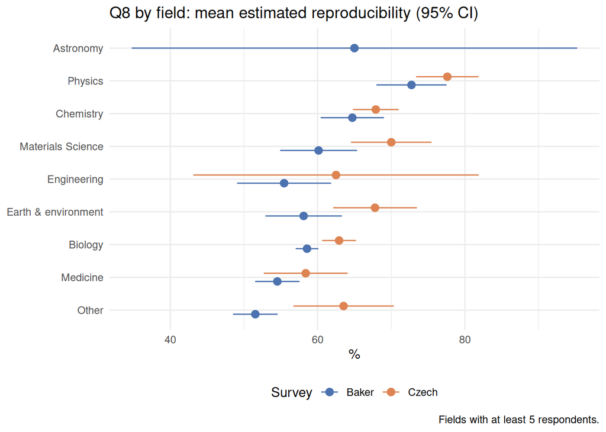

```r
byf <- q8 %>% filter(!is.na(field)) %>% group_by(Survey, field) %>% filter(n() >= 5) %>% reframe(wci(pct))
ggplot(byf, aes(x = mean, y = factor(field, levels = rev(intersect(hard_order, unique(field)))), colour = Survey)) +
  geom_pointrange(aes(xmin = lo, xmax = hi), position = position_dodge(width = 0.5)) +
  scale_colour_manual(values = pal) +
  labs(title = "Q8 by field: mean estimated reproducibility (95% CI)", x = "%", y = NULL,
       caption = "Fields with at least 5 respondents.") +
  theme_minimal() + theme(legend.position = "bottom")
```

```r
kable(byf %>% mutate(across(where(is.double), ~ round(.x, 1))) %>% arrange(match(field, hard_order), Survey))
```

| Survey | field | N | mean | lo | hi |
| --- | --- | --- | --- | --- | --- |
| Baker | Astronomy | 6 | 65.0 | 34.8 | 95.2 |
| Baker | Physics | 91 | 72.7 | 68.0 | 77.5 |
| Czech | Physics | 113 | 77.6 | 73.4 | 81.9 |
| Baker | Chemistry | 106 | 64.7 | 60.4 | 69.0 |
| Czech | Chemistry | 119 | 67.9 | 64.8 | 71.0 |
| Baker | Materials Science | 73 | 60.1 | 54.9 | 65.4 |
| Czech | Materials Science | 61 | 70.0 | 64.5 | 75.5 |
| Baker | Engineering | 66 | 55.5 | 49.1 | 61.8 |
| Czech | Engineering | 12 | 62.5 | 43.1 | 81.9 |
| Baker | Earth & environment | 95 | 58.1 | 52.9 | 63.3 |
| Czech | Earth & environment | 68 | 67.8 | 62.1 | 73.5 |
| Baker | Biology | 703 | 58.6 | 57.0 | 60.1 |
| Czech | Biology | 305 | 62.9 | 60.6 | 65.2 |
| Baker | Medicine | 203 | 54.5 | 51.5 | 57.5 |
| Czech | Medicine | 62 | 58.4 | 52.7 | 64.1 |
| Baker | Other | 233 | 51.5 | 48.5 | 54.6 |
| Czech | Other | 34 | 63.5 | 56.7 | 70.3 |

## Q9 – Attitude statements

Baker’s “major problem for all fields” has no Czech counterpart. Q9d (“increase during my career”) is Czech only and is reported in `sample.Rmd`.

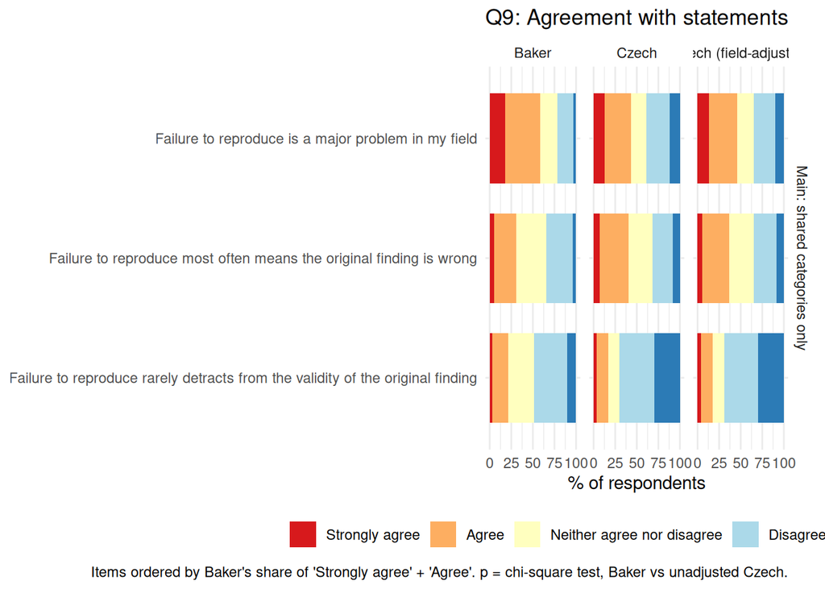

Share agreeing (strongly agree + agree)

| Version | item | % Baker | % Czech | % Czech (field-adjusted) | N Baker | N Czech | p |
| --- | --- | --- | --- | --- | --- | --- | --- |
| Main: shared categories only | Failure to reproduce is a major problem in my field | 58.8 | 43.0 | 46.2 | 1576 | 812 | <1e-04 |
| Main: shared categories only | Failure to reproduce most often means the original finding is wrong | 30.6 | 40.7 | 36.6 | 1576 | 843 | <1e-04 |
| Main: shared categories only | Failure to reproduce rarely detracts from the validity of the original finding | 21.8 | 17.0 | 17.6 | 1576 | 833 | <1e-04 |

```r
r <- compare_battery(names(q9), q9, agree, top = c("Strongly agree", "Agree"), versions = v_main,
                     title = "Q9: Agreement with statements")
r$plot; kable(r$table, caption = "Share agreeing (strongly agree + agree)")
```

## Q16 – Factors contributing to irreproducible research

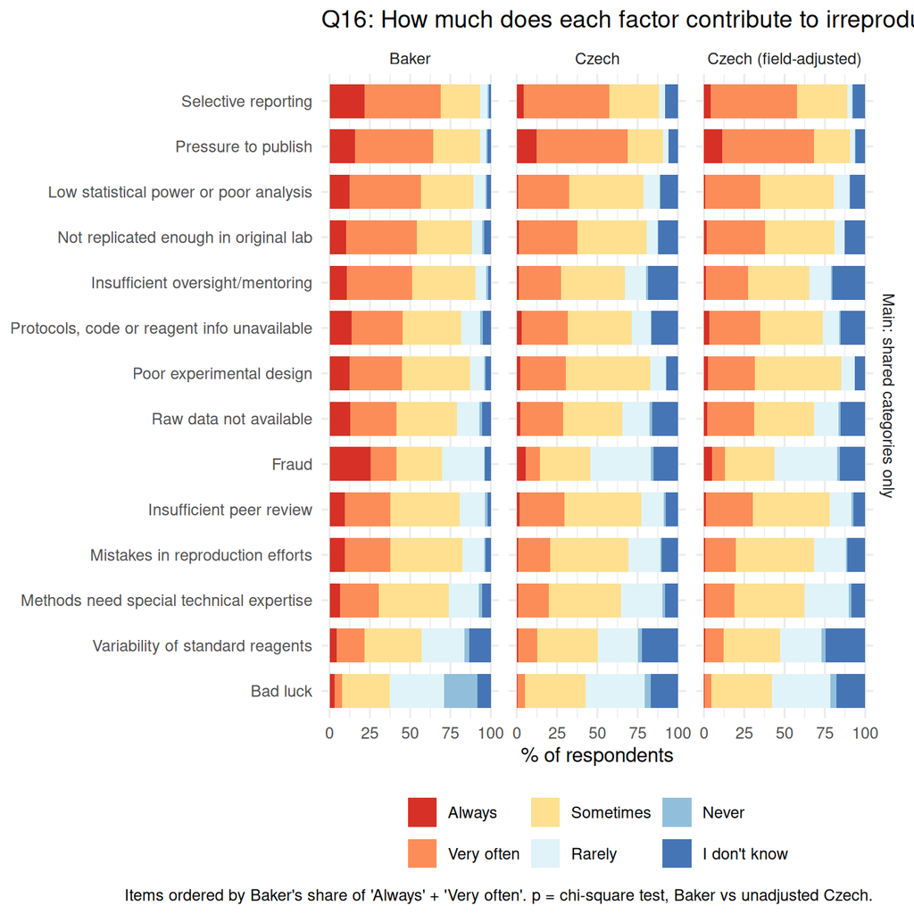

Share answering always + very often

| Version | item | % Baker | % Czech | % Czech (field-adjusted) | N Baker | N Czech | p |
| --- | --- | --- | --- | --- | --- | --- | --- |
| Main: shared categories only | Selective reporting | 68.8 | 57.5 | 57.6 | 1576 | 857 | <1e-04 |
| Main: shared categories only | Pressure to publish | 64.4 | 68.7 | 68.3 | 1576 | 860 | <1e-04 |
| Main: shared categories only | Low statistical power or poor analysis | 56.6 | 32.7 | 34.8 | 1576 | 850 | <1e-04 |
| Main: shared categories only | Not replicated enough in original lab | 54.1 | 37.6 | 37.7 | 1576 | 852 | <1e-04 |
| Main: shared categories only | Insufficient oversight/mentoring | 51.4 | 27.5 | 27.3 | 1576 | 851 | <1e-04 |
| Main: shared categories only | Protocols, code or reagent info unavailable | 45.4 | 31.7 | 35.1 | 1576 | 849 | <1e-04 |
| Main: shared categories only | Poor experimental design | 45.1 | 30.3 | 31.7 | 1576 | 855 | <1e-04 |
| Main: shared categories only | Raw data not available | 41.7 | 28.7 | 31.2 | 1576 | 850 | <1e-04 |
| Main: shared categories only | Fraud | 41.4 | 14.4 | 12.9 | 1576 | 854 | <1e-04 |
| Main: shared categories only | Insufficient peer review | 37.9 | 29.6 | 30.4 | 1576 | 859 | <1e-04 |
| Main: shared categories only | Mistakes in reproduction efforts | 37.7 | 20.6 | 19.6 | 1576 | 849 | <1e-04 |
| Main: shared categories only | Methods need special technical expertise | 30.5 | 20.0 | 19.1 | 1576 | 849 | <1e-04 |
| Main: shared categories only | Variability of standard reagents | 21.5 | 12.6 | 12.0 | 1576 | 854 | <1e-04 |
| Main: shared categories only | Bad luck | 7.7 | 5.1 | 4.4 | 1576 | 847 | <1e-04 |

```r
r <- compare_battery(names(q16), q16, often, top = c("Always", "Very often"), versions = v_main_kp,
                     title = "Q16: How much does each factor contribute to irreproducibility?")
r$plot; kable(r$table, caption = "Share answering always + very often")
```

## Q18 – Failed to reproduce my own experiment

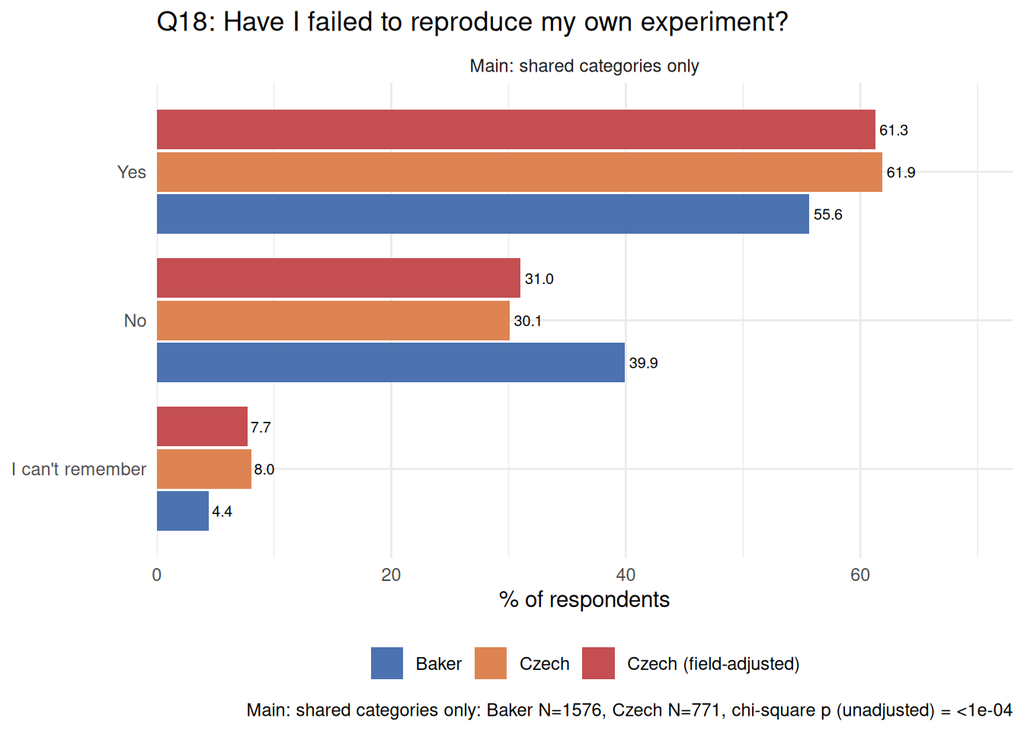

| Version | Answer | n Baker | n Czech | % Baker | % Czech | % Czech (field-adjusted) |
| --- | --- | --- | --- | --- | --- | --- |
| Main: shared categories only | Yes | 877 | 477 | 55.6 | 61.9 | 61.3 |
| Main: shared categories only | No | 629 | 232 | 39.9 | 30.1 | 31.0 |
| Main: shared categories only | I can’t remember | 70 | 62 | 4.4 | 8.0 | 7.7 |

```r
r <- compare_cat("nerep_jaMuj", yn, versions = v_main_exp, title = "Q18: Have I failed to reproduce my own experiment?"); r$plot; kable(r$table)
```

## Q19 – Failed to reproduce someone else’s experiment

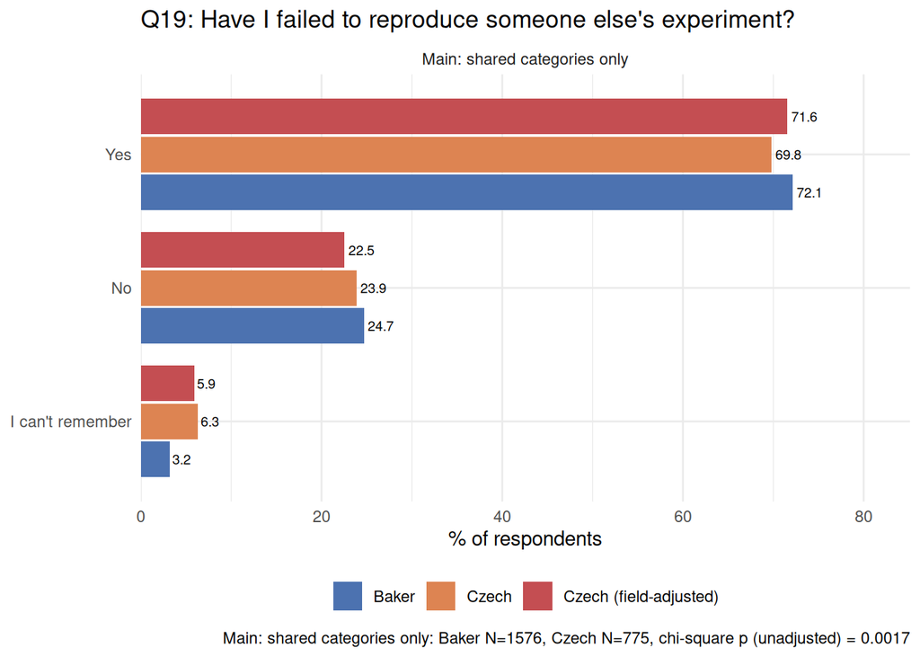

| Version | Answer | n Baker | n Czech | % Baker | % Czech | % Czech (field-adjusted) |
| --- | --- | --- | --- | --- | --- | --- |
| Main: shared categories only | Yes | 1137 | 541 | 72.1 | 69.8 | 71.6 |
| Main: shared categories only | No | 389 | 185 | 24.7 | 23.9 | 22.5 |
| Main: shared categories only | I can’t remember | 50 | 49 | 3.2 | 6.3 | 5.9 |

```r
r <- compare_cat("nerep_jaCizi", yn, versions = v_main_exp, title = "Q19: Have I failed to reproduce someone else's experiment?"); r$plot; kable(r$table)
```

## Q20 – Someone failed to reproduce my results

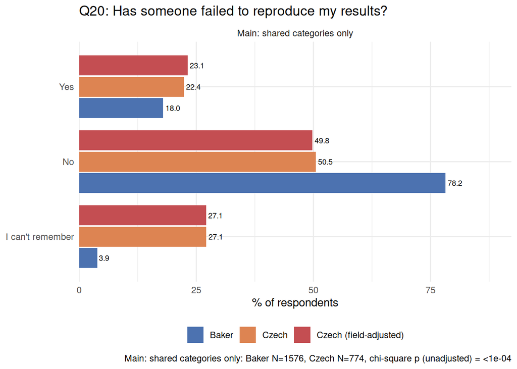

| Version | Answer | n Baker | n Czech | % Baker | % Czech | % Czech (field-adjusted) |
| --- | --- | --- | --- | --- | --- | --- |
| Main: shared categories only | Yes | 283 | 173 | 18.0 | 22.4 | 23.1 |
| Main: shared categories only | No | 1232 | 391 | 78.2 | 50.5 | 49.8 |
| Main: shared categories only | I can’t remember | 61 | 210 | 3.9 | 27.1 | 27.1 |

```r
r <- compare_cat("nerep_oniMuj", yn, versions = v_main_exp, title = "Q20: Has someone failed to reproduce my results?"); r$plot; kable(r$table)
```

## By field (Q6, Q18, Q19, Q20)

Answer spectra by field in % (Baker / Czech), with Cramér’s V (bias-corrected) per field and question. Same basis as Part 1. Small cells (n < 20) are unreliable.

```r
abbr <- c("Significant crisis" = "Sig", "Slight crisis" = "Sli", "No crisis" = "No", "I don't know" = "DK",
          "Yes" = "Yes", "No" = "No", "I can't remember" = "CR", "I don't do experiments" = "NoExp")
field_table <- function(bf, drops) {
  spec <- bf %>% mutate(answer = factor(answer, levels = names(ans_cols))) %>% arrange(answer) %>%
    group_by(Q, var, field, Survey, N) %>%
    summarise(dist = paste0(abbr[as.character(answer)], " ", round(pct), collapse = ", "), .groups = "drop") %>%
    pivot_wider(names_from = Survey, values_from = c(N, dist))
  keys <- spec %>% distinct(Q, var, field)
  vv <- bind_rows(lapply(seq_len(nrow(keys)), function(i) {
    vr <- keys$var[i]; fl <- keys$field[i]
    x <- d[d$Survey %in% c("Baker", "Czech") & d$field %in% fl & !is.na(d[[vr]]) & !d[[vr]] %in% drops[[vr]], ]
    v_of(x$Survey, x[[vr]]) %>% mutate(Q = keys$Q[i], field = fl)
  })) %>% select(Q, field, V, lo, hi)
  spec %>% left_join(vv, by = c("Q", "field")) %>%
    mutate(field = factor(field, levels = field_order(bf))) %>% arrange(parse_number(Q), field) %>%
    transmute(Question = Q, Field = field, `N Baker` = N_Baker, `N Czech` = N_Czech,
              `Baker %` = dist_Baker, `Czech %` = dist_Czech,
              `V [95% CI]` = sprintf("%.2f [%.2f, %.2f]", V, lo, hi), Size = cohen(V))
}
field_table(bf_main, list(krize_rep = character(0), nerep_jaMuj = NOX, nerep_jaCizi = NOX, nerep_oniMuj = NOX)) %>%
  kable(caption = "Sig/Sli/No/DK = significant/slight/no crisis/don't know; CR = can't remember; NoExp = don't do experiments.")
```

Sig/Sli/No/DK = significant/slight/no crisis/don’t know; CR = can’t remember; NoExp = don’t do experiments.

| Question | Field | N Baker | N Czech | Baker % | Czech % | V [95% CI] | Size |
| --- | --- | --- | --- | --- | --- | --- | --- |
| Q6 | Astronomy | 6 | 6 | Sig 67, Sli 33 | Sig 17, No 17, DK 67 | 0.71 [0.00, 1.00] | large |
| Q6 | Physics | 91 | 125 | Sig 41, Sli 43, No 5, DK 11 | Sig 23, Sli 24, No 18, DK 34 | 0.35 [0.19, 0.48] | medium |
| Q6 | Chemistry | 106 | 131 | Sig 44, Sli 42, No 4, DK 9 | Sig 38, Sli 31, No 8, DK 23 | 0.19 [0.00, 0.31] | small |
| Q6 | Materials Science | 73 | 67 | Sig 53, Sli 40, DK 7 | Sig 30, Sli 24, No 21, DK 25 | 0.44 [0.24, 0.60] | medium |
| Q6 | Engineering | 66 | 15 | Sig 50, Sli 41, No 2, DK 8 | Sig 40, Sli 33, No 13, DK 13 | 0.18 [0.00, 0.40] | small |
| Q6 | Earth & environment | 95 | 86 | Sig 39, Sli 42, No 4, DK 15 | Sig 26, Sli 21, No 15, DK 38 | 0.34 [0.15, 0.48] | medium |
| Q6 | Biology | 703 | 330 | Sig 54, Sli 38, No 2, DK 6 | Sig 38, Sli 30, No 8, DK 25 | 0.31 [0.25, 0.37] | medium |
| Q6 | Medicine | 203 | 81 | Sig 60, Sli 29, No 4, DK 7 | Sig 32, Sli 25, No 14, DK 30 | 0.35 [0.21, 0.46] | medium |
| Q6 | Other | 233 | 38 | Sig 51, Sli 36, No 4, DK 8 | Sig 42, Sli 24, No 5, DK 29 | 0.21 [0.00, 0.32] | small |
| Q18 | Astronomy | 6 | 3 | Yes 33, No 67 | Yes 100 | 0.56 [0.00, 1.00] | large |
| Q18 | Physics | 91 | 109 | Yes 45, No 45, CR 10 | Yes 55, No 34, CR 11 | 0.05 [0.00, 0.22] | negligible |
| Q18 | Chemistry | 106 | 124 | Yes 64, No 30, CR 6 | Yes 75, No 20, CR 5 | 0.08 [0.00, 0.22] | negligible |
| Q18 | Materials Science | 73 | 65 | Yes 63, No 32, CR 5 | Yes 71, No 17, CR 12 | 0.15 [0.00, 0.32] | small |
| Q18 | Engineering | 66 | 12 | Yes 47, No 45, CR 8 | Yes 100 | 0.35 [0.00, 0.57] | medium |
| Q18 | Earth & environment | 95 | 55 | Yes 41, No 57, CR 2 | Yes 36, No 53, CR 11 | 0.15 [0.00, 0.32] | small |
| Q18 | Biology | 703 | 305 | Yes 60, No 36, CR 4 | Yes 63, No 29, CR 8 | 0.10 [0.00, 0.16] | negligible |
| Q18 | Medicine | 203 | 65 | Yes 56, No 41, CR 3 | Yes 54, No 43, CR 3 | 0.00 [0.00, 0.00] | negligible |
| Q18 | Other | 233 | 33 | Yes 49, No 47, CR 4 | Yes 45, No 45, CR 9 | 0.00 [0.00, 0.15] | negligible |
| Q19 | Astronomy | 6 | 3 | Yes 50, No 50 | Yes 100 | 0.38 [0.00, 1.00] | medium |
| Q19 | Physics | 91 | 107 | Yes 55, No 37, CR 8 | Yes 50, No 41, CR 9 | 0.00 [0.00, 0.13] | negligible |
| Q19 | Chemistry | 106 | 125 | Yes 87, No 9, CR 4 | Yes 85, No 9, CR 6 | 0.00 [0.00, 0.14] | negligible |
| Q19 | Materials Science | 73 | 65 | Yes 75, No 25 | Yes 68, No 25, CR 8 | 0.17 [0.00, 0.34] | small |
| Q19 | Engineering | 66 | 12 | Yes 82, No 15, CR 3 | Yes 58, No 33, CR 8 | 0.13 [0.00, 0.38] | small |
| Q19 | Earth & environment | 95 | 55 | Yes 64, No 35, CR 1 | Yes 53, No 40, CR 7 | 0.14 [0.00, 0.31] | small |
| Q19 | Biology | 703 | 306 | Yes 77, No 20, CR 3 | Yes 74, No 21, CR 5 | 0.05 [0.00, 0.11] | negligible |
| Q19 | Medicine | 203 | 68 | Yes 67, No 31, CR 2 | Yes 68, No 28, CR 4 | 0.00 [0.00, 0.12] | negligible |
| Q19 | Other | 233 | 34 | Yes 62, No 33, CR 5 | Yes 76, No 18, CR 6 | 0.07 [0.00, 0.20] | negligible |
| Q20 | Astronomy | 6 | 3 | Yes 33, No 67 | Yes 67, CR 33 | 0.53 [0.00, 1.00] | large |
| Q20 | Physics | 91 | 107 | Yes 18, No 75, CR 8 | Yes 18, No 58, CR 24 | 0.20 [0.00, 0.34] | small |
| Q20 | Chemistry | 106 | 126 | Yes 20, No 75, CR 5 | Yes 27, No 44, CR 29 | 0.34 [0.20, 0.47] | medium |
| Q20 | Materials Science | 73 | 64 | Yes 25, No 71, CR 4 | Yes 19, No 48, CR 33 | 0.36 [0.16, 0.52] | medium |
| Q20 | Engineering | 66 | 12 | Yes 14, No 82, CR 5 | Yes 8, No 50, CR 42 | 0.41 [0.12, 0.64] | medium |
| Q20 | Earth & environment | 95 | 55 | Yes 13, No 83, CR 4 | Yes 13, No 67, CR 20 | 0.23 [0.00, 0.39] | small |
| Q20 | Biology | 703 | 306 | Yes 19, No 78, CR 4 | Yes 23, No 49, CR 28 | 0.37 [0.31, 0.43] | medium |
| Q20 | Medicine | 203 | 67 | Yes 21, No 75, CR 3 | Yes 27, No 48, CR 25 | 0.34 [0.21, 0.46] | medium |
| Q20 | Other | 233 | 34 | Yes 13, No 85, CR 2 | Yes 29, No 50, CR 21 | 0.34 [0.20, 0.45] | medium |

Q18–Q20, “yes” and “no” only: field’s “yes” share and its deviation from the survey’s overall share (all cells shown).

```r
yd_main <- yes_dev(c("Yes", "No"))
yes_table(yd_main) %>% kable()
```

| Question | Field | Survey | n | Yes % | Overall yes % | Difference, pp [95% CI] |
| --- | --- | --- | --- | --- | --- | --- |
| Q18: Failed to reproduce own experiment | Astronomy | Baker | 6 | 33.3 | 58.2 | -24.9 [-62.6, 12.8] |
| Q18: Failed to reproduce own experiment | Astronomy | Czech | 3 | 100.0 | 67.3 | 32.7 [29.3, 36.2] |
| Q18: Failed to reproduce own experiment | Physics | Baker | 82 | 50.0 | 58.2 | -8.2 [-18.7, 2.3] |
| Q18: Failed to reproduce own experiment | Physics | Czech | 97 | 61.9 | 67.3 | -5.4 [-14.4, 3.5] |
| Q18: Failed to reproduce own experiment | Chemistry | Baker | 100 | 68.0 | 58.2 | 9.8 [0.9, 18.6] |
| Q18: Failed to reproduce own experiment | Chemistry | Czech | 118 | 78.8 | 67.3 | 11.5 [4.6, 18.5] |
| Q18: Failed to reproduce own experiment | Materials Science | Baker | 69 | 66.7 | 58.2 | 8.4 [-2.5, 19.3] |
| Q18: Failed to reproduce own experiment | Materials Science | Czech | 57 | 80.7 | 67.3 | 13.4 [3.4, 23.4] |
| Q18: Failed to reproduce own experiment | Engineering | Baker | 61 | 50.8 | 58.2 | -7.4 [-19.7, 4.9] |
| Q18: Failed to reproduce own experiment | Engineering | Czech | 12 | 100.0 | 67.3 | 32.7 [29.3, 36.2] |
| Q18: Failed to reproduce own experiment | Earth & environment | Baker | 93 | 41.9 | 58.2 | -16.3 [-26.0, -6.6] |
| Q18: Failed to reproduce own experiment | Earth & environment | Czech | 49 | 40.8 | 67.3 | -26.5 [-39.7, -13.2] |
| Q18: Failed to reproduce own experiment | Biology | Baker | 676 | 62.6 | 58.2 | 4.3 [1.6, 7.1] |
| Q18: Failed to reproduce own experiment | Biology | Czech | 280 | 68.9 | 67.3 | 1.7 [-2.6, 5.9] |
| Q18: Failed to reproduce own experiment | Medicine | Baker | 196 | 57.7 | 58.2 | -0.6 [-7.0, 5.9] |
| Q18: Failed to reproduce own experiment | Medicine | Czech | 63 | 55.6 | 67.3 | -11.7 [-23.4, -0.1] |
| Q18: Failed to reproduce own experiment | Other | Baker | 223 | 51.1 | 58.2 | -7.1 [-13.2, -1.1] |
| Q18: Failed to reproduce own experiment | Other | Czech | 30 | 50.0 | 67.3 | -17.3 [-34.7, 0.2] |
| Q19: Failed to reproduce someone else’s experiment | Astronomy | Baker | 6 | 50.0 | 74.5 | -24.5 [-64.4, 15.4] |
| Q19: Failed to reproduce someone else’s experiment | Astronomy | Czech | 3 | 100.0 | 74.5 | 25.5 [22.3, 28.6] |
| Q19: Failed to reproduce someone else’s experiment | Physics | Baker | 84 | 59.5 | 74.5 | -15.0 [-25.1, -4.8] |
| Q19: Failed to reproduce someone else’s experiment | Physics | Czech | 97 | 54.6 | 74.5 | -19.9 [-28.9, -10.8] |
| Q19: Failed to reproduce someone else’s experiment | Chemistry | Baker | 102 | 90.2 | 74.5 | 15.7 [9.9, 21.5] |
| Q19: Failed to reproduce someone else’s experiment | Chemistry | Czech | 117 | 90.6 | 74.5 | 16.1 [10.7, 21.4] |
| Q19: Failed to reproduce someone else’s experiment | Materials Science | Baker | 73 | 75.3 | 74.5 | 0.8 [-8.8, 10.5] |
| Q19: Failed to reproduce someone else’s experiment | Materials Science | Czech | 60 | 73.3 | 74.5 | -1.2 [-11.9, 9.5] |
| Q19: Failed to reproduce someone else’s experiment | Engineering | Baker | 64 | 84.4 | 74.5 | 9.9 [1.1, 18.7] |
| Q19: Failed to reproduce someone else’s experiment | Engineering | Czech | 11 | 63.6 | 74.5 | -10.9 [-39.1, 17.3] |
| Q19: Failed to reproduce someone else’s experiment | Earth & environment | Baker | 94 | 64.9 | 74.5 | -9.6 [-18.9, -0.3] |
| Q19: Failed to reproduce someone else’s experiment | Earth & environment | Czech | 51 | 56.9 | 74.5 | -17.7 [-30.6, -4.7] |
| Q19: Failed to reproduce someone else’s experiment | Biology | Baker | 684 | 79.2 | 74.5 | 4.7 [2.3, 7.1] |
| Q19: Failed to reproduce someone else’s experiment | Biology | Czech | 290 | 78.3 | 74.5 | 3.8 [-0.1, 7.6] |
| Q19: Failed to reproduce someone else’s experiment | Medicine | Baker | 198 | 68.7 | 74.5 | -5.8 [-11.8, 0.2] |
| Q19: Failed to reproduce someone else’s experiment | Medicine | Czech | 65 | 70.8 | 74.5 | -3.7 [-14.3, 6.8] |
| Q19: Failed to reproduce someone else’s experiment | Other | Baker | 221 | 65.2 | 74.5 | -9.4 [-15.1, -3.6] |
| Q19: Failed to reproduce someone else’s experiment | Other | Czech | 32 | 81.2 | 74.5 | 6.7 [-6.6, 20.0] |
| Q20: Someone failed to reproduce my results | Astronomy | Baker | 6 | 33.3 | 18.7 | 14.7 [-23.0, 52.3] |
| Q20: Someone failed to reproduce my results | Astronomy | Czech | 2 | 100.0 | 30.7 | 69.3 [65.5, 73.1] |
| Q20: Someone failed to reproduce my results | Physics | Baker | 84 | 19.0 | 18.7 | 0.4 [-7.8, 8.5] |
| Q20: Someone failed to reproduce my results | Physics | Czech | 81 | 23.5 | 30.7 | -7.2 [-15.9, 1.5] |
| Q20: Someone failed to reproduce my results | Chemistry | Baker | 101 | 20.8 | 18.7 | 2.1 [-5.5, 9.7] |
| Q20: Someone failed to reproduce my results | Chemistry | Czech | 90 | 37.8 | 30.7 | 7.1 [-2.0, 16.2] |
| Q20: Someone failed to reproduce my results | Materials Science | Baker | 70 | 25.7 | 18.7 | 7.0 [-2.9, 17.0] |
| Q20: Someone failed to reproduce my results | Materials Science | Czech | 43 | 27.9 | 30.7 | -2.8 [-15.7, 10.1] |
| Q20: Someone failed to reproduce my results | Engineering | Baker | 63 | 14.3 | 18.7 | -4.4 [-12.9, 4.1] |
| Q20: Someone failed to reproduce my results | Engineering | Czech | 7 | 14.3 | 30.7 | -16.4 [-42.3, 9.5] |
| Q20: Someone failed to reproduce my results | Earth & environment | Baker | 91 | 13.2 | 18.7 | -5.5 [-12.3, 1.3] |
| Q20: Someone failed to reproduce my results | Earth & environment | Czech | 44 | 15.9 | 30.7 | -14.8 [-25.4, -4.1] |
| Q20: Someone failed to reproduce my results | Biology | Baker | 676 | 19.4 | 18.7 | 0.7 [-1.5, 2.9] |
| Q20: Someone failed to reproduce my results | Biology | Czech | 220 | 31.8 | 30.7 | 1.1 [-3.6, 5.9] |
| Q20: Someone failed to reproduce my results | Medicine | Baker | 196 | 21.9 | 18.7 | 3.3 [-2.1, 8.6] |
| Q20: Someone failed to reproduce my results | Medicine | Czech | 50 | 36.0 | 30.7 | 5.3 [-7.3, 18.0] |
| Q20: Someone failed to reproduce my results | Other | Baker | 228 | 13.6 | 18.7 | -5.1 [-9.3, -0.9] |
| Q20: Someone failed to reproduce my results | Other | Czech | 27 | 37.0 | 30.7 | 6.4 [-11.4, 24.1] |

Kruskal–Wallis tests of differences between fields in the “yes” share (Q18–Q20, “yes” and “no” only, fields with n ≥ 20):

```r
kw_tests(kd_main) %>% mutate(H = round(H, 2), p = fmt_p(p)) %>%
  rename(Question = Q) %>% kable()
```

| Question | Survey | H | df | p | Fields | N |
| --- | --- | --- | --- | --- | --- | --- |
| Q18: Failed to reproduce own experiment | Baker | 29.66 | 7 | 0.00011 | 8 | 1500 |
| Q18: Failed to reproduce own experiment | Czech | 36.42 | 6 | < 1e-04 | 7 | 694 |
| Q19: Failed to reproduce someone else’s experiment | Baker | 52.89 | 7 | < 1e-04 | 8 | 1520 |
| Q19: Failed to reproduce someone else’s experiment | Czech | 47.94 | 6 | < 1e-04 | 7 | 712 |
| Q20: Someone failed to reproduce my results | Baker | 10.67 | 7 | 0.15348 | 8 | 1509 |
| Q20: Someone failed to reproduce my results | Czech | 10.09 | 6 | 0.12087 | 7 | 555 |

# Part 3: Sensitivity analysis – all answer categories

All categories kept, including those offered in one survey only: “don’t know” in Q8 and Q9, “I don’t do experiments” in Q18–Q20, and the one-survey Q5 options. Categories present in only one survey raise V by construction.

## Size of the differences

```r
vall <- v_summary(character(0), character(0), character(0), names(q5))
vall %>% v_fmt() %>% left_join(v_fmt(vmain) %>% select(Question, Main = `V [95% CI]`, `Size, main` = Size), by = "Question") %>%
  transmute(Question, Item, `N Baker` = nB, `N Czech` = nC, `V [95% CI], all categories` = `V [95% CI]`,
            `Size, all` = Size, `V [95% CI], main` = Main, `Size, main`) %>% kable()
```

| Question | Item | N Baker | N Czech | V [95% CI], all categories | Size, all | V [95% CI], main | Size, main |
| --- | --- | --- | --- | --- | --- | --- | --- |
| Q5 | Heard of the crisis, and where (options as one distribution) | 1576 | 884 | 0.50 [0.47, 0.53] | medium | 0.33 [0.29, 0.36] | medium |
| Q6 | Is there a reproducibility crisis? | 1576 | 879 | 0.34 [0.30, 0.38] | medium | 0.34 [0.30, 0.38] | medium |
| Q8 | Share of published results reproducible | 1576 | 878 | 0.33 [0.28, 0.36] | medium | 0.18 [0.13, 0.22] | small |
| Q9 | Attitude statements (3 items as one distribution) | 1576 | 869 | 0.27 [0.24, 0.29] | small | 0.22 [0.19, 0.24] | small |
| Q16 | Factors of irreproducibility (14 items as one distribution) | 1576 | 868 | 0.25 [0.23, 0.25] | small | 0.25 [0.23, 0.25] | small |
| Q18 | Failed to reproduce own experiment | 1576 | 857 | 0.28 [0.24, 0.32] | small | 0.11 [0.06, 0.15] | small |
| Q19 | Failed to reproduce someone else’s experiment | 1576 | 861 | 0.27 [0.22, 0.30] | small | 0.07 [0.00, 0.11] | negligible |
| Q20 | Someone failed to reproduce my results | 1576 | 858 | 0.43 [0.39, 0.47] | medium | 0.36 [0.32, 0.40] | medium |

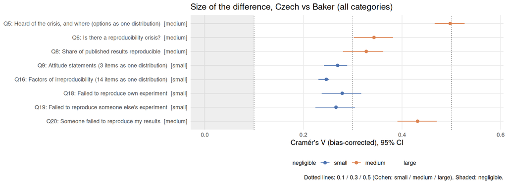

```r
v_plot(vall, "Size of the difference, Czech vs Baker (all categories)")
```

## Q5 – Awareness (all options)

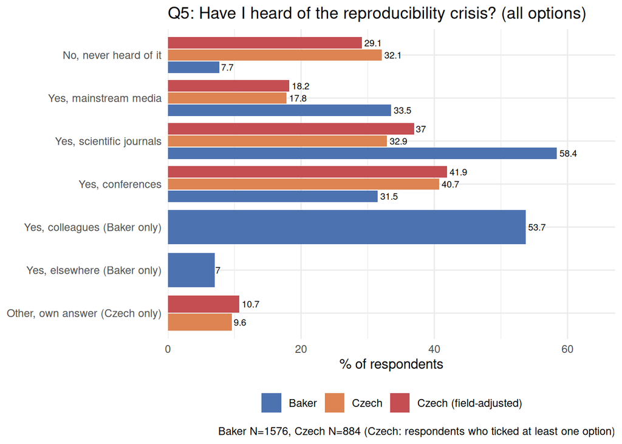

| item | % Baker | % Czech | % Czech (field-adjusted) |
| --- | --- | --- | --- |
| Yes, scientific journals | 58.4 | 32.9 | 37.0 |
| Yes, conferences | 31.5 | 40.7 | 41.9 |
| Yes, elsewhere (Baker only) | 7.0 | NA | NA |
| Yes, colleagues (Baker only) | 53.7 | NA | NA |
| Yes, mainstream media | 33.5 | 17.8 | 18.2 |
| No, never heard of it | 7.7 | 32.1 | 29.1 |
| Other, own answer (Czech only) | NA | 9.6 | 10.7 |

```r
r <- q5_show(names(q5), "Q5: Have I heard of the reproducibility crisis? (all options)"); r$plot; kable(r$table)
```

## Q6 – Is there a reproducibility crisis?

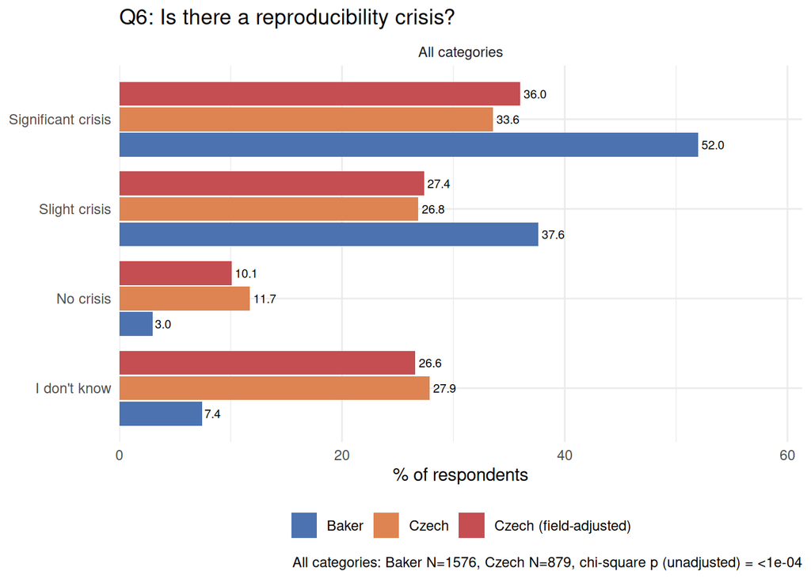

| Version | Answer | n Baker | n Czech | % Baker | % Czech | % Czech (field-adjusted) |
| --- | --- | --- | --- | --- | --- | --- |
| All categories | Significant crisis | 819 | 295 | 52.0 | 33.6 | 36.0 |
| All categories | Slight crisis | 593 | 236 | 37.6 | 26.8 | 27.4 |
| All categories | No crisis | 47 | 103 | 3.0 | 11.7 | 10.1 |
| All categories | I don’t know | 117 | 245 | 7.4 | 27.9 | 26.6 |

```r
r <- compare_cat("krize_rep", crisis, versions = v_all, title = "Q6: Is there a reproducibility crisis?"); r$plot; kable(r$table)
```

## Q8 – Share of published results in my field that are reproducible

Baker had no “don’t know” option. Means (Part 2) always exclude “don’t know”.

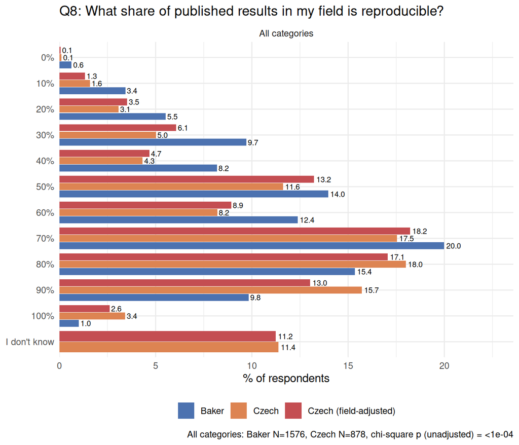

| Version | Answer | n Baker | n Czech | % Baker | % Czech | % Czech (field-adjusted) |
| --- | --- | --- | --- | --- | --- | --- |
| All categories | 0% | 10 | 1 | 0.6 | 0.1 | 0.1 |
| All categories | 10% | 54 | 14 | 3.4 | 1.6 | 1.3 |
| All categories | 20% | 87 | 27 | 5.5 | 3.1 | 3.5 |
| All categories | 30% | 153 | 44 | 9.7 | 5.0 | 6.1 |
| All categories | 40% | 129 | 38 | 8.2 | 4.3 | 4.7 |
| All categories | 50% | 220 | 102 | 14.0 | 11.6 | 13.2 |
| All categories | 60% | 195 | 72 | 12.4 | 8.2 | 8.9 |
| All categories | 70% | 315 | 154 | 20.0 | 17.5 | 18.2 |
| All categories | 80% | 242 | 158 | 15.4 | 18.0 | 17.1 |
| All categories | 90% | 155 | 138 | 9.8 | 15.7 | 13.0 |
| All categories | 100% | 16 | 30 | 1.0 | 3.4 | 2.6 |
| All categories | I don’t know | 0 | 100 | 0.0 | 11.4 | 11.2 |

```r
r <- compare_cat("rep_podil", lv8, versions = v_all, title = "Q8: What share of published results in my field is reproducible?"); r$plot; kable(r$table)
```

## Q9 – Attitude statements

Baker had no “don’t know” option.

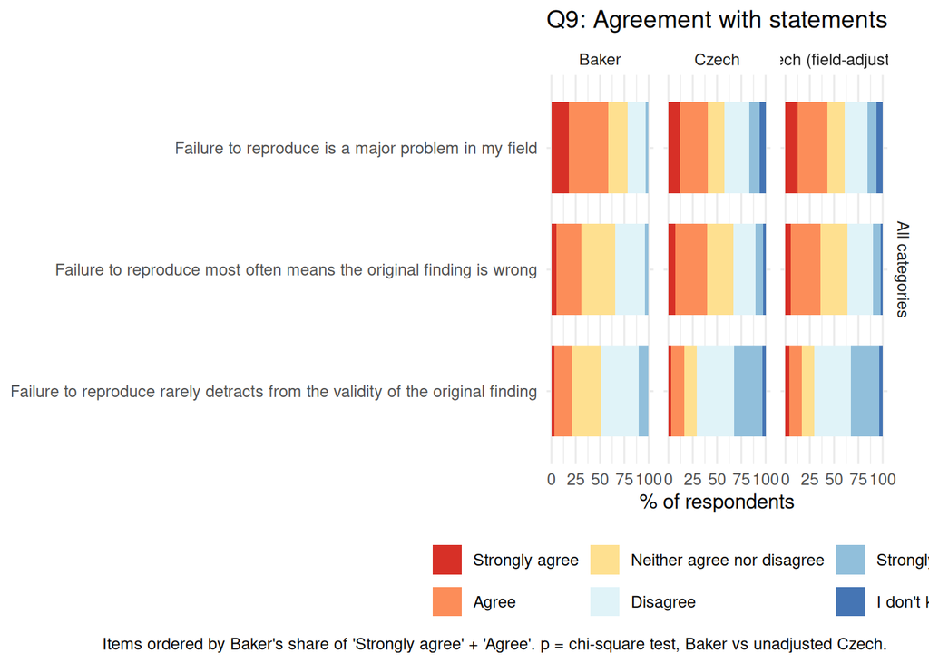

Share agreeing (strongly agree + agree)

| Version | item | % Baker | % Czech | % Czech (field-adjusted) | N Baker | N Czech | p |
| --- | --- | --- | --- | --- | --- | --- | --- |
| All categories | Failure to reproduce is a major problem in my field | 58.8 | 40.3 | 43.3 | 1576 | 865 | <1e-04 |
| All categories | Failure to reproduce most often means the original finding is wrong | 30.6 | 39.7 | 35.8 | 1576 | 864 | <1e-04 |
| All categories | Failure to reproduce rarely detracts from the validity of the original finding | 21.8 | 16.4 | 17.0 | 1576 | 864 | <1e-04 |

```r
r <- compare_battery(names(q9), q9, agree, top = c("Strongly agree", "Agree"), versions = v_all,
                     title = "Q9: Agreement with statements")
r$plot; kable(r$table, caption = "Share agreeing (strongly agree + agree)")
```

## Q16 – Factors contributing to irreproducible research

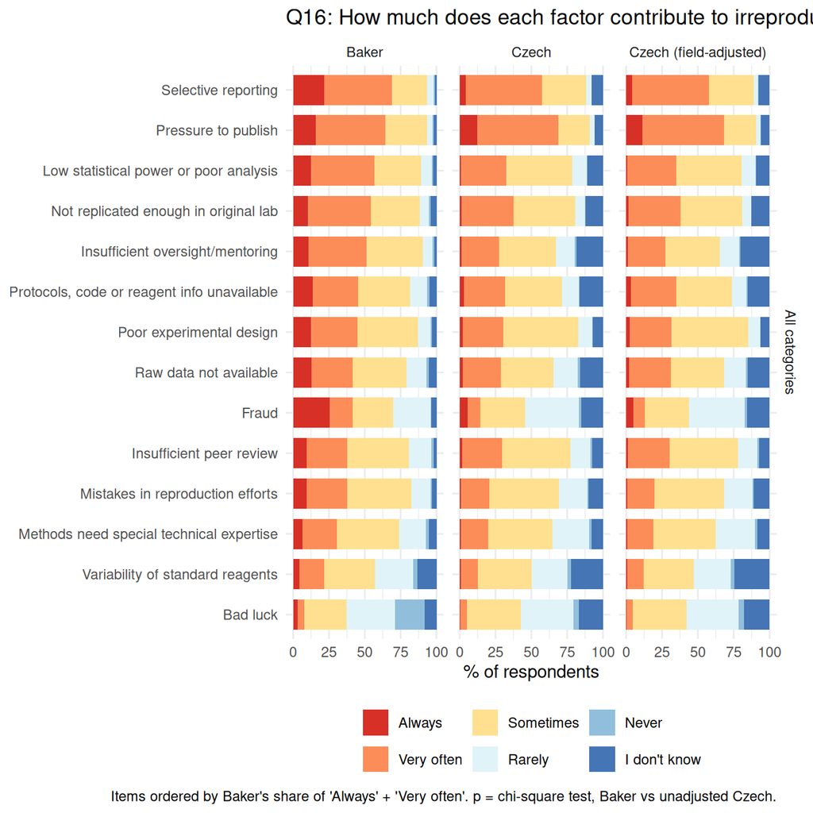

Share answering always + very often

| Version | item | % Baker | % Czech | % Czech (field-adjusted) | N Baker | N Czech | p |
| --- | --- | --- | --- | --- | --- | --- | --- |
| All categories | Selective reporting | 68.8 | 57.5 | 57.6 | 1576 | 857 | <1e-04 |
| All categories | Pressure to publish | 64.4 | 68.7 | 68.3 | 1576 | 860 | <1e-04 |
| All categories | Low statistical power or poor analysis | 56.6 | 32.7 | 34.8 | 1576 | 850 | <1e-04 |
| All categories | Not replicated enough in original lab | 54.1 | 37.6 | 37.7 | 1576 | 852 | <1e-04 |
| All categories | Insufficient oversight/mentoring | 51.4 | 27.5 | 27.3 | 1576 | 851 | <1e-04 |
| All categories | Protocols, code or reagent info unavailable | 45.4 | 31.7 | 35.1 | 1576 | 849 | <1e-04 |
| All categories | Poor experimental design | 45.1 | 30.3 | 31.7 | 1576 | 855 | <1e-04 |
| All categories | Raw data not available | 41.7 | 28.7 | 31.2 | 1576 | 850 | <1e-04 |
| All categories | Fraud | 41.4 | 14.4 | 12.9 | 1576 | 854 | <1e-04 |
| All categories | Insufficient peer review | 37.9 | 29.6 | 30.4 | 1576 | 859 | <1e-04 |
| All categories | Mistakes in reproduction efforts | 37.7 | 20.6 | 19.6 | 1576 | 849 | <1e-04 |
| All categories | Methods need special technical expertise | 30.5 | 20.0 | 19.1 | 1576 | 849 | <1e-04 |
| All categories | Variability of standard reagents | 21.5 | 12.6 | 12.0 | 1576 | 854 | <1e-04 |
| All categories | Bad luck | 7.7 | 5.1 | 4.4 | 1576 | 847 | <1e-04 |

```r
r <- compare_battery(names(q16), q16, often, top = c("Always", "Very often"), versions = v_all,
                     title = "Q16: How much does each factor contribute to irreproducibility?")
r$plot; kable(r$table, caption = "Share answering always + very often")
```

## Q18 – Failed to reproduce my own experiment

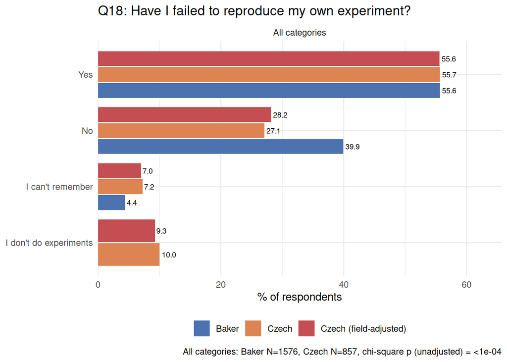

| Version | Answer | n Baker | n Czech | % Baker | % Czech | % Czech (field-adjusted) |
| --- | --- | --- | --- | --- | --- | --- |
| All categories | Yes | 877 | 477 | 55.6 | 55.7 | 55.6 |
| All categories | No | 629 | 232 | 39.9 | 27.1 | 28.2 |
| All categories | I can’t remember | 70 | 62 | 4.4 | 7.2 | 7.0 |
| All categories | I don’t do experiments | 0 | 86 | 0.0 | 10.0 | 9.3 |

```r
r <- compare_cat("nerep_jaMuj", yn, versions = v_all, title = "Q18: Have I failed to reproduce my own experiment?"); r$plot; kable(r$table)
```

## Q19 – Failed to reproduce someone else’s experiment

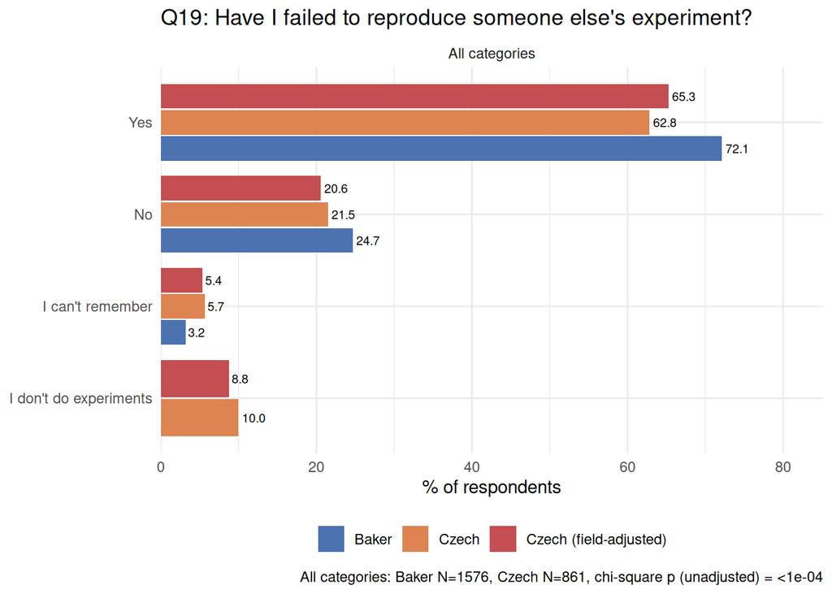

| Version | Answer | n Baker | n Czech | % Baker | % Czech | % Czech (field-adjusted) |
| --- | --- | --- | --- | --- | --- | --- |
| All categories | Yes | 1137 | 541 | 72.1 | 62.8 | 65.3 |
| All categories | No | 389 | 185 | 24.7 | 21.5 | 20.6 |
| All categories | I can’t remember | 50 | 49 | 3.2 | 5.7 | 5.4 |
| All categories | I don’t do experiments | 0 | 86 | 0.0 | 10.0 | 8.8 |

```r
r <- compare_cat("nerep_jaCizi", yn, versions = v_all, title = "Q19: Have I failed to reproduce someone else's experiment?"); r$plot; kable(r$table)
```

## Q20 – Someone failed to reproduce my results

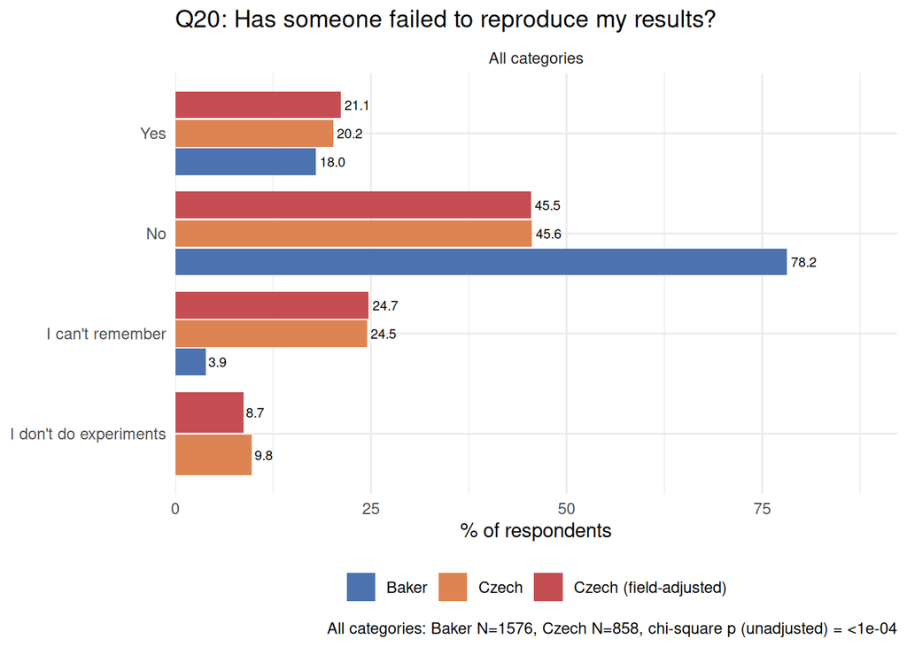

| Version | Answer | n Baker | n Czech | % Baker | % Czech | % Czech (field-adjusted) |
| --- | --- | --- | --- | --- | --- | --- |
| All categories | Yes | 283 | 173 | 18.0 | 20.2 | 21.1 |
| All categories | No | 1232 | 391 | 78.2 | 45.6 | 45.5 |
| All categories | I can’t remember | 61 | 210 | 3.9 | 24.5 | 24.7 |
| All categories | I don’t do experiments | 0 | 84 | 0.0 | 9.8 | 8.7 |

```r
r <- compare_cat("nerep_oniMuj", yn, versions = v_all, title = "Q20: Has someone failed to reproduce my results?"); r$plot; kable(r$table)
```

## By field (Q6, Q18, Q19, Q20), all categories

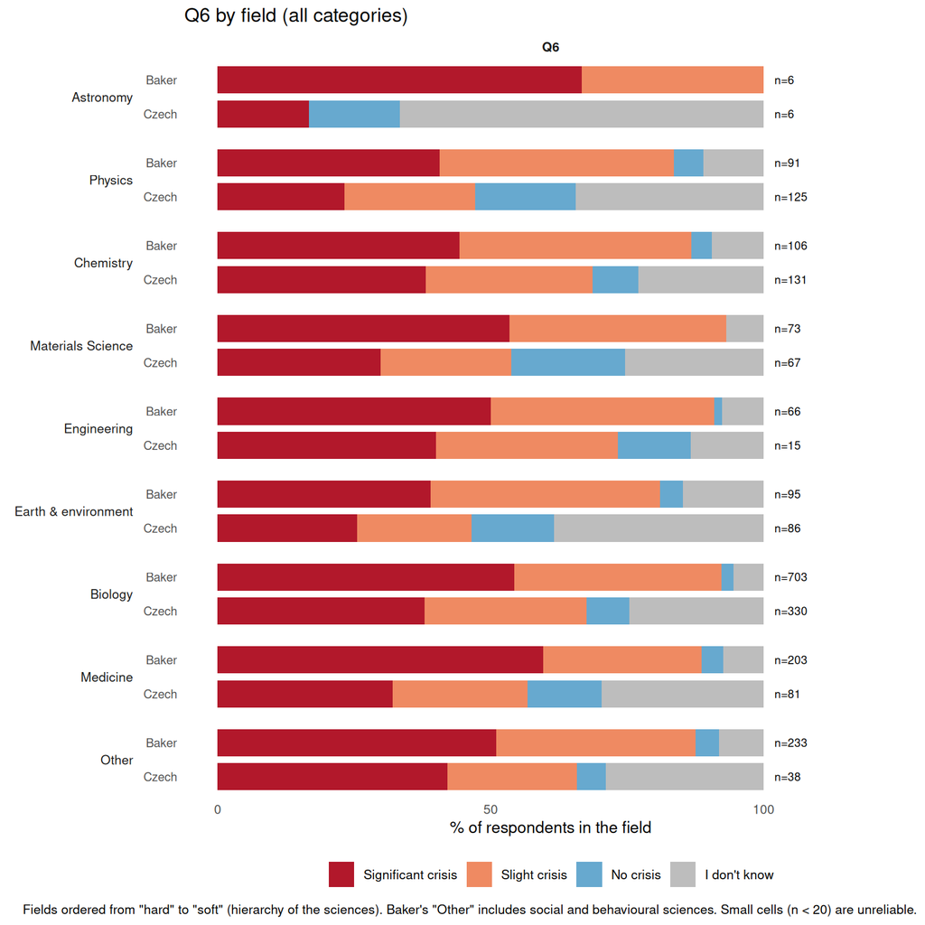

```r
none <- list(krize_rep = character(0), nerep_jaMuj = character(0), nerep_jaCizi = character(0), nerep_oniMuj = character(0))
bf_all <- by_field(none)
field_plot(bf_all, "Q6", "Q6 by field (all categories)")
```

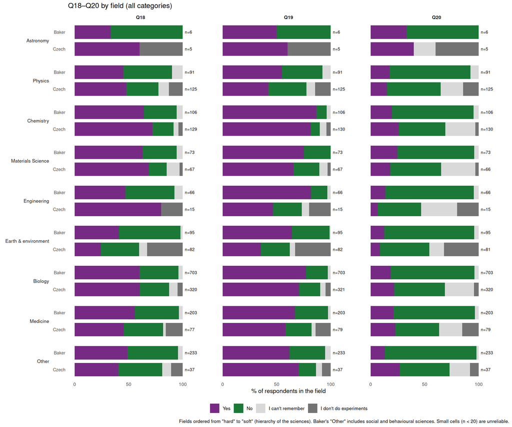

```r
field_plot(bf_all, c("Q18", "Q19", "Q20"), "Q18–Q20 by field (all categories)")
```

```r
field_table(bf_all, none) %>% kable()
```

| Question | Field | N Baker | N Czech | Baker % | Czech % | V [95% CI] | Size |
| --- | --- | --- | --- | --- | --- | --- | --- |
| Q6 | Astronomy | 6 | 6 | Sig 67, Sli 33 | Sig 17, No 17, DK 67 | 0.71 [0.00, 1.00] | large |
| Q6 | Physics | 91 | 125 | Sig 41, Sli 43, No 5, DK 11 | Sig 23, Sli 24, No 18, DK 34 | 0.35 [0.19, 0.48] | medium |
| Q6 | Chemistry | 106 | 131 | Sig 44, Sli 42, No 4, DK 9 | Sig 38, Sli 31, No 8, DK 23 | 0.19 [0.00, 0.31] | small |
| Q6 | Materials Science | 73 | 67 | Sig 53, Sli 40, DK 7 | Sig 30, Sli 24, No 21, DK 25 | 0.44 [0.24, 0.60] | medium |
| Q6 | Engineering | 66 | 15 | Sig 50, Sli 41, No 2, DK 8 | Sig 40, Sli 33, No 13, DK 13 | 0.18 [0.00, 0.40] | small |
| Q6 | Earth & environment | 95 | 86 | Sig 39, Sli 42, No 4, DK 15 | Sig 26, Sli 21, No 15, DK 38 | 0.34 [0.15, 0.48] | medium |
| Q6 | Biology | 703 | 330 | Sig 54, Sli 38, No 2, DK 6 | Sig 38, Sli 30, No 8, DK 25 | 0.31 [0.25, 0.37] | medium |
| Q6 | Medicine | 203 | 81 | Sig 60, Sli 29, No 4, DK 7 | Sig 32, Sli 25, No 14, DK 30 | 0.35 [0.21, 0.46] | medium |
| Q6 | Other | 233 | 38 | Sig 51, Sli 36, No 4, DK 8 | Sig 42, Sli 24, No 5, DK 29 | 0.21 [0.00, 0.32] | small |
| Q18 | Astronomy | 6 | 5 | Yes 33, No 67 | Yes 60, NoExp 40 | 0.63 [0.00, 1.00] | large |
| Q18 | Physics | 91 | 125 | Yes 45, No 45, CR 10 | Yes 48, No 30, CR 10, NoExp 13 | 0.24 [0.00, 0.37] | small |
| Q18 | Chemistry | 106 | 129 | Yes 64, No 30, CR 6 | Yes 72, No 19, CR 5, NoExp 4 | 0.14 [0.00, 0.27] | small |
| Q18 | Materials Science | 73 | 67 | Yes 63, No 32, CR 5 | Yes 69, No 16, CR 12, NoExp 3 | 0.18 [0.00, 0.34] | small |
| Q18 | Engineering | 66 | 15 | Yes 47, No 45, CR 8 | Yes 80, NoExp 20 | 0.51 [0.22, 0.72] | large |
| Q18 | Earth & environment | 95 | 82 | Yes 41, No 57, CR 2 | Yes 24, No 35, CR 7, NoExp 33 | 0.47 [0.30, 0.61] | medium |
| Q18 | Biology | 703 | 320 | Yes 60, No 36, CR 4 | Yes 60, No 27, CR 8, NoExp 5 | 0.20 [0.13, 0.26] | small |
| Q18 | Medicine | 203 | 77 | Yes 56, No 41, CR 3 | Yes 45, No 36, CR 3, NoExp 16 | 0.33 [0.19, 0.44] | medium |
| Q18 | Other | 233 | 37 | Yes 49, No 47, CR 4 | Yes 41, No 41, CR 8, NoExp 11 | 0.30 [0.15, 0.41] | small |
| Q19 | Astronomy | 6 | 5 | Yes 50, No 50 | Yes 60, NoExp 40 | 0.53 [0.00, 1.00] | large |
| Q19 | Physics | 91 | 125 | Yes 55, No 37, CR 8 | Yes 42, No 35, CR 8, NoExp 14 | 0.24 [0.00, 0.36] | small |
| Q19 | Chemistry | 106 | 130 | Yes 87, No 9, CR 4 | Yes 82, No 8, CR 6, NoExp 4 | 0.09 [0.00, 0.22] | negligible |
| Q19 | Materials Science | 73 | 67 | Yes 75, No 25 | Yes 66, No 24, CR 7, NoExp 3 | 0.19 [0.00, 0.35] | small |
| Q19 | Engineering | 66 | 15 | Yes 82, No 15, CR 3 | Yes 47, No 27, CR 7, NoExp 20 | 0.41 [0.00, 0.62] | medium |
| Q19 | Earth & environment | 95 | 82 | Yes 64, No 35, CR 1 | Yes 35, No 27, CR 5, NoExp 33 | 0.47 [0.30, 0.61] | medium |
| Q19 | Biology | 703 | 321 | Yes 77, No 20, CR 3 | Yes 71, No 20, CR 5, NoExp 5 | 0.18 [0.11, 0.24] | small |
| Q19 | Medicine | 203 | 79 | Yes 67, No 31, CR 2 | Yes 58, No 24, CR 4, NoExp 14 | 0.31 [0.17, 0.42] | medium |
| Q19 | Other | 233 | 37 | Yes 62, No 33, CR 5 | Yes 70, No 16, CR 5, NoExp 8 | 0.27 [0.11, 0.38] | small |
| Q20 | Astronomy | 6 | 5 | Yes 33, No 67 | Yes 40, CR 20, NoExp 40 | 0.61 [0.00, 1.00] | large |
| Q20 | Physics | 91 | 125 | Yes 18, No 75, CR 8 | Yes 15, No 50, CR 21, NoExp 14 | 0.32 [0.14, 0.45] | medium |
| Q20 | Chemistry | 106 | 130 | Yes 20, No 75, CR 5 | Yes 26, No 43, CR 28, NoExp 3 | 0.36 [0.20, 0.48] | medium |
| Q20 | Materials Science | 73 | 66 | Yes 25, No 71, CR 4 | Yes 18, No 47, CR 32, NoExp 3 | 0.37 [0.14, 0.53] | medium |
| Q20 | Engineering | 66 | 15 | Yes 14, No 82, CR 5 | Yes 7, No 40, CR 33, NoExp 20 | 0.55 [0.27, 0.75] | large |
| Q20 | Earth & environment | 95 | 81 | Yes 13, No 83, CR 4 | Yes 9, No 46, CR 14, NoExp 32 | 0.49 [0.32, 0.63] | medium |
| Q20 | Biology | 703 | 320 | Yes 19, No 78, CR 4 | Yes 22, No 47, CR 27, NoExp 4 | 0.40 [0.34, 0.46] | medium |
| Q20 | Medicine | 203 | 79 | Yes 21, No 75, CR 3 | Yes 23, No 41, CR 22, NoExp 15 | 0.46 [0.33, 0.58] | medium |
| Q20 | Other | 233 | 37 | Yes 13, No 85, CR 2 | Yes 27, No 46, CR 19, NoExp 8 | 0.41 [0.28, 0.53] | medium |

Q18–Q20 deviations with the “yes” share taken over all answers (“I can’t remember” and “I don’t do experiments” included):

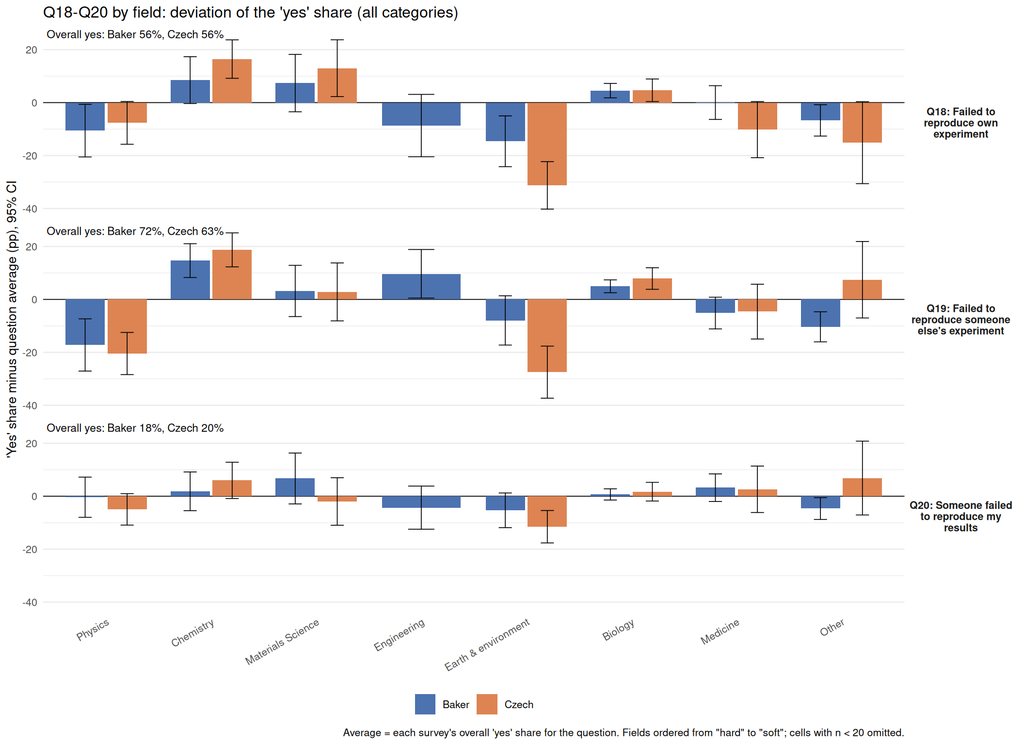

```r
yd_all <- yes_dev(c("Yes", "No", CR, NOX))
yes_plot(yd_all, "Q18-Q20 by field: deviation of the 'yes' share (all categories)")
```

```r
yes_table(yd_all) %>% kable()
```

| Question | Field | Survey | n | Yes % | Overall yes % | Difference, pp [95% CI] |
| --- | --- | --- | --- | --- | --- | --- |
| Q18: Failed to reproduce own experiment | Astronomy | Baker | 6 | 33.3 | 55.6 | -22.3 [-60.0, 15.3] |
| Q18: Failed to reproduce own experiment | Astronomy | Czech | 5 | 60.0 | 55.7 | 4.3 [-38.5, 47.2] |
| Q18: Failed to reproduce own experiment | Physics | Baker | 91 | 45.1 | 55.6 | -10.6 [-20.5, -0.7] |
| Q18: Failed to reproduce own experiment | Physics | Czech | 125 | 48.0 | 55.7 | -7.7 [-15.7, 0.4] |
| Q18: Failed to reproduce own experiment | Chemistry | Baker | 106 | 64.2 | 55.6 | 8.5 [-0.3, 17.3] |
| Q18: Failed to reproduce own experiment | Chemistry | Czech | 129 | 72.1 | 55.7 | 16.4 [9.2, 23.7] |
| Q18: Failed to reproduce own experiment | Materials Science | Baker | 73 | 63.0 | 55.6 | 7.4 [-3.5, 18.2] |
| Q18: Failed to reproduce own experiment | Materials Science | Czech | 67 | 68.7 | 55.7 | 13.0 [2.3, 23.7] |
| Q18: Failed to reproduce own experiment | Engineering | Baker | 66 | 47.0 | 55.6 | -8.7 [-20.5, 3.1] |
| Q18: Failed to reproduce own experiment | Engineering | Czech | 15 | 80.0 | 55.7 | 24.3 [4.2, 44.5] |
| Q18: Failed to reproduce own experiment | Earth & environment | Baker | 95 | 41.1 | 55.6 | -14.6 [-24.2, -5.0] |
| Q18: Failed to reproduce own experiment | Earth & environment | Czech | 82 | 24.4 | 55.7 | -31.3 [-40.2, -22.3] |
| Q18: Failed to reproduce own experiment | Biology | Baker | 703 | 60.2 | 55.6 | 4.5 [1.8, 7.2] |
| Q18: Failed to reproduce own experiment | Biology | Czech | 320 | 60.3 | 55.7 | 4.7 [0.4, 8.9] |
| Q18: Failed to reproduce own experiment | Medicine | Baker | 203 | 55.7 | 55.6 | 0.0 [-6.4, 6.4] |
| Q18: Failed to reproduce own experiment | Medicine | Czech | 77 | 45.5 | 55.7 | -10.2 [-20.8, 0.4] |
| Q18: Failed to reproduce own experiment | Other | Baker | 233 | 48.9 | 55.6 | -6.7 [-12.6, -0.8] |
| Q18: Failed to reproduce own experiment | Other | Czech | 37 | 40.5 | 55.7 | -15.1 [-30.6, 0.4] |
| Q19: Failed to reproduce someone else’s experiment | Astronomy | Baker | 6 | 50.0 | 72.1 | -22.1 [-62.1, 17.8] |
| Q19: Failed to reproduce someone else’s experiment | Astronomy | Czech | 5 | 60.0 | 62.8 | -2.8 [-45.6, 40.0] |
| Q19: Failed to reproduce someone else’s experiment | Physics | Baker | 91 | 54.9 | 72.1 | -17.2 [-27.1, -7.3] |
| Q19: Failed to reproduce someone else’s experiment | Physics | Czech | 125 | 42.4 | 62.8 | -20.4 [-28.4, -12.5] |
| Q19: Failed to reproduce someone else’s experiment | Chemistry | Baker | 106 | 86.8 | 72.1 | 14.6 [8.3, 21.0] |
| Q19: Failed to reproduce someone else’s experiment | Chemistry | Czech | 130 | 81.5 | 62.8 | 18.7 [12.3, 25.1] |
| Q19: Failed to reproduce someone else’s experiment | Materials Science | Baker | 73 | 75.3 | 72.1 | 3.2 [-6.5, 12.9] |
| Q19: Failed to reproduce someone else’s experiment | Materials Science | Czech | 67 | 65.7 | 62.8 | 2.8 [-8.1, 13.8] |
| Q19: Failed to reproduce someone else’s experiment | Engineering | Baker | 66 | 81.8 | 72.1 | 9.7 [0.5, 18.9] |
| Q19: Failed to reproduce someone else’s experiment | Engineering | Czech | 15 | 46.7 | 62.8 | -16.2 [-41.2, 8.8] |
| Q19: Failed to reproduce someone else’s experiment | Earth & environment | Baker | 95 | 64.2 | 72.1 | -7.9 [-17.2, 1.4] |
| Q19: Failed to reproduce someone else’s experiment | Earth & environment | Czech | 82 | 35.4 | 62.8 | -27.5 [-37.3, -17.6] |
| Q19: Failed to reproduce someone else’s experiment | Biology | Baker | 703 | 77.1 | 72.1 | 5.0 [2.5, 7.4] |
| Q19: Failed to reproduce someone else’s experiment | Biology | Czech | 321 | 70.7 | 62.8 | 7.9 [3.8, 12.0] |
| Q19: Failed to reproduce someone else’s experiment | Medicine | Baker | 203 | 67.0 | 72.1 | -5.1 [-11.1, 0.8] |
| Q19: Failed to reproduce someone else’s experiment | Medicine | Czech | 79 | 58.2 | 62.8 | -4.6 [-14.9, 5.7] |
| Q19: Failed to reproduce someone else’s experiment | Other | Baker | 233 | 61.8 | 72.1 | -10.3 [-16.0, -4.7] |
| Q19: Failed to reproduce someone else’s experiment | Other | Czech | 37 | 70.3 | 62.8 | 7.4 [-7.0, 21.9] |
| Q20: Someone failed to reproduce my results | Astronomy | Baker | 6 | 33.3 | 18.0 | 15.4 [-22.2, 53.0] |
| Q20: Someone failed to reproduce my results | Astronomy | Czech | 5 | 40.0 | 20.2 | 19.8 [-22.9, 62.6] |
| Q20: Someone failed to reproduce my results | Physics | Baker | 91 | 17.6 | 18.0 | -0.4 [-8.0, 7.2] |
| Q20: Someone failed to reproduce my results | Physics | Czech | 125 | 15.2 | 20.2 | -5.0 [-10.9, 1.0] |
| Q20: Someone failed to reproduce my results | Chemistry | Baker | 106 | 19.8 | 18.0 | 1.9 [-5.5, 9.2] |
| Q20: Someone failed to reproduce my results | Chemistry | Czech | 130 | 26.2 | 20.2 | 6.0 [-0.9, 12.8] |
| Q20: Someone failed to reproduce my results | Materials Science | Baker | 73 | 24.7 | 18.0 | 6.7 [-2.9, 16.3] |
| Q20: Someone failed to reproduce my results | Materials Science | Czech | 66 | 18.2 | 20.2 | -2.0 [-11.0, 7.0] |
| Q20: Someone failed to reproduce my results | Engineering | Baker | 66 | 13.6 | 18.0 | -4.3 [-12.5, 3.8] |
| Q20: Someone failed to reproduce my results | Engineering | Czech | 15 | 6.7 | 20.2 | -13.5 [-26.2, -0.8] |
| Q20: Someone failed to reproduce my results | Earth & environment | Baker | 95 | 12.6 | 18.0 | -5.3 [-11.9, 1.2] |
| Q20: Someone failed to reproduce my results | Earth & environment | Czech | 81 | 8.6 | 20.2 | -11.5 [-17.6, -5.4] |
| Q20: Someone failed to reproduce my results | Biology | Baker | 703 | 18.6 | 18.0 | 0.7 [-1.4, 2.8] |
| Q20: Someone failed to reproduce my results | Biology | Czech | 320 | 21.9 | 20.2 | 1.7 [-1.8, 5.2] |
| Q20: Someone failed to reproduce my results | Medicine | Baker | 203 | 21.2 | 18.0 | 3.2 [-2.0, 8.4] |
| Q20: Someone failed to reproduce my results | Medicine | Czech | 79 | 22.8 | 20.2 | 2.6 [-6.2, 11.4] |
| Q20: Someone failed to reproduce my results | Other | Baker | 233 | 13.3 | 18.0 | -4.7 [-8.8, -0.5] |
| Q20: Someone failed to reproduce my results | Other | Czech | 37 | 27.0 | 20.2 | 6.9 [-7.1, 20.8] |

# Appendix: checks against the Baker reference values

```r
tibble(
  Check = c("Significant crisis", "Slight crisis", "No crisis", "Don't know", "Mean Q8 (%)",
            "Failed to reproduce own", "Failed to reproduce others'"),
  Expected = c(52.0, 37.6, 3.0, 7.4, 58.18, 55.6, 72.1),
  Computed = c(100 * mean(bk$krize_rep == "There is a significant crisis of reproducibility"),
               100 * mean(bk$krize_rep == "There is a slight crisis of reproducibility"),
               100 * mean(bk$krize_rep == "There is no crisis of reproducibility"),
               100 * mean(bk$krize_rep == "I don't know"),
               mean(parse_number(bk$rep_podil)),
               100 * mean(bk$nerep_jaMuj == "Yes"), 100 * mean(bk$nerep_jaCizi == "Yes"))) %>%
  mutate(Computed = round(Computed, 2)) %>% kable()
```

| Check | Expected | Computed |
| --- | --- | --- |
| Significant crisis | 52.00 | 51.97 |
| Slight crisis | 37.60 | 37.63 |
| No crisis | 3.00 | 2.98 |
| Don’t know | 7.40 | 7.42 |
| Mean Q8 (%) | 58.18 | 58.18 |
| Failed to reproduce own | 55.60 | 55.65 |
| Failed to reproduce others’ | 72.10 | 72.14 |